# RelativeSize

2026-02-16 10:41

## Design

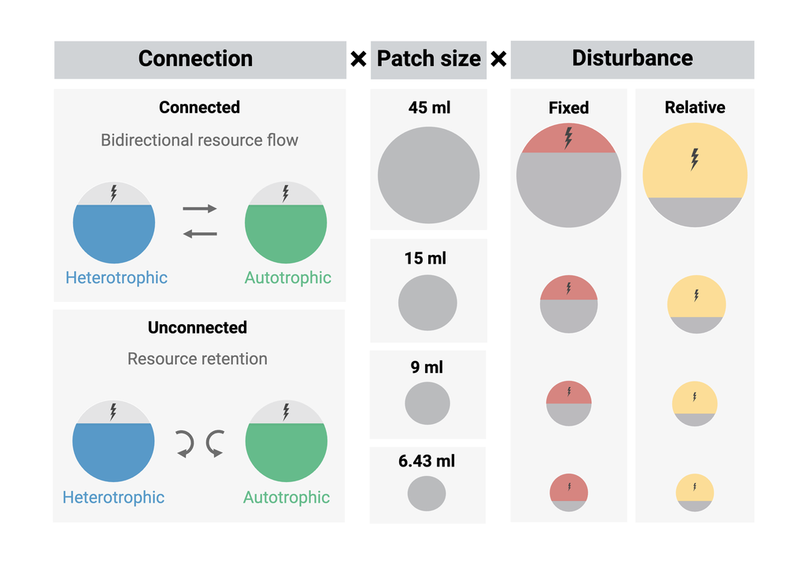

Figure 1. Experimental design. Light-coloured section of the ecosystem with lightning bolt = portion disturbed to be turn into nonliving resources and exchanged between ecosystems (in connected meta-ecosystems) or retained (in unconnected meta-ecosystems). Ecosystem treatments were replicated six times (2 trophic types x 2 connection types x 4 ecosystem sizes * 2 disturbed volume types * 6 replicates = 192 ecosystems).

## Parameters

```r
# --- SET PARAMETERS FOR R MARKDOWN AND THE GENERAL RUNNING OF THE CODE --- #

knitr::opts_chunk$set(message = FALSE,
                      cache = FALSE,
                      autodep = FALSE)
start_time = Sys.time()
recompute_analyses = FALSE
```

```r
# --- SET PARAMETERS NECESSARY TO USE THE PACKAGE BEMOVI (INCLUDES SAMPLING PARAMETERS) --- #

# Define time points and associated sampling days

time_points = 0:7
sampling_days = c(0, 4, 8, 12, 16, 20, 24, 28)

# Define parameters used for analysing the videos in the package BEMOVI

fps = 25  # Frames per second (frame rate of the video)
seconds_per_video = 5  # Duration of each video in seconds
total_frames = fps * seconds_per_video  # Total number of frames in each video
measured_volume = 34.4  # Volume measured for each video in microliters (µL)
volume_recorded_μl = measured_volume  # Storing the measured volume in µL
volume_recorded_ml = volume_recorded_μl * 10**-3  # Converting the volume from µL to milliliters (mL)
pixel_to_scale = 4.05  # Conversion factor for pixels to µm
filter_min_net_disp = 25  # Minimum net displacement for an object to be considered a protist (pixels)
filter_min_duration = 1  # Minimum duration an object must be tracked to be considered a protist (seconds)
filter_detection_freq = 0.1  # Minimum frequency of detection in the video for an object to be considered a protist (detected frames / total frames)
filter_median_step_length = 3  # Minimum step length for an object to be considered a protist (pixels)
threshold_levels = c(13, 40) # Two lower pixel intensity thresholds for ImageJ to distinguish background from protists (higher threshold used for Ble)
video.description.folder = "0_video_description/" # Folder where the video descriptions (metadata about each video) are stored
video.description.file = "video_description.txt" # Filename of the text file containing the description of each video
merged_data_folder = "5_merged_data/" # Folder where the merged data files from the analysis will be stored

# Define columns that will be used for identifying species based on their movement and morphological characteristics

columns_for_species_ID = c(
  "mean_grey",         # Mean grayscale value (intensity) of the detected protist (brightness)
  "sd_grey",           # Standard deviation of the grayscale values (intensity variation)
  "mean_area",         # Mean area (in pixels) of the detected protist
  "sd_area",           # Standard deviation of the protist's area
  "mean_perimeter",    # Mean perimeter (length around the protist) of the detected protist
  "mean_turning",      # Mean turning angle of the protist's trajectory (how much the protist changes direction)
  "sd_turning",        # Standard deviation of the turning angles (variability in direction change)
  "sd_perimeter",      # Standard deviation of the protist's perimeter
  "mean_major",        # Mean length of the major axis of the protist (longest dimension)
  "sd_major",          # Standard deviation of the major axis length
  "mean_minor",        # Mean length of the minor axis of the protist (shortest dimension)
  "sd_minor",          # Standard deviation of the minor axis length
  "mean_ar",           # Mean aspect ratio (ratio of major to minor axis length)
  "sd_ar",             # Standard deviation of the aspect ratio
  "duration",          # Duration of time the protist is tracked in the video
  "max_net",           # Maximum net displacement (greatest straight-line distance traveled)
  "net_disp",          # Total net displacement (total straight-line distance from start to end of the trajectory)
  "net_speed",         # Mean net speed (speed based on net displacement)
  "gross_disp",        # Total gross displacement (total distance traveled including all movement)
  "max_step",          # Maximum step length (largest distance moved between two consecutive frames)
  "min_step",          # Minimum step length (smallest distance moved between two consecutive frames)
  "sd_step",           # Standard deviation of the step lengths (variability in frame-to-frame movement)
  "sd_gross_speed",    # Standard deviation of gross speed (variability in speed over time)
  "max_gross_speed",   # Maximum gross speed (highest speed achieved)
  "min_gross_speed")    # Minimum gross speed (lowest speed detected)
```

```r
# --- SET PARAMETERS RELATED TO RESOURCE FLOWS --- #

resource_flow_days = c(5, 9, 13, 17, 21, 25)
volume_disturbed_across_sizes_levels = c("fixed", "relative")
fixed_label = "Volume disturbed FIXED acroos ecosystem sizes"
relative_label = "Volume disturbed RELATIVE to ecosystem size"
```

```r
# --- SET PARAMETERS RELATED TO PROTISTS --- #

protist_species = c("Ble",
                    "Cep",
                    "Col",
                    "Eug",
                    "Eup",
                    "Lox",
                    "Pau",
                    "Pca",
                    "Spi",
                    "Spi_te",
                    "Tet")
protist_sepcies_ordered_by_size = c("Tet",
                                     "Col",
                                     "Eup",
                                     "Pau",
                                     "Cep",
                                     "Lox",
                                     "Pca",
                                     "Spi_te",
                                     "Ble",
                                     "Spi")
protist_species_indiv_per_ml = paste0(protist_species, "_indiv_per_ml")
protist_species_bioarea_mm2_per_ml = paste0(protist_species, "_bioarea_mm2_per_ml")
protist_species_dominance = paste0(protist_species_bioarea_mm2_per_ml, "_dominance")
```

```r
# --- SET PARAMETERS RELATED TO INDIVIDUALS --- #

# Initialise the dataset "ds_individuals" and "training_individuals"

ds_individuals = list()
training_individuals = list()
```

```r
# --- SET PARAMETERS RELATED TO ECOSYSTEMS --- #

# Initialise the dataset "ds_ecosystems_effect_size"

ds_ecosystems_effect_size = list()

# Define ecosystems to take off because of problems in the experiment

ecosystems_to_take_off = NA

# Define the variables you want to calculate for each ecosystem

variables_ecosystems = c("bioarea_mm2_per_ml",
                        "indiv_per_ml",
                        "species_richness",
                        "shannon",
                        "evenness_pielou",
                        protist_species_dominance)

# Number of ecosystems

n_ecosystems = 192

# Metaecosystem IDs

metaecosystem_ID_vector_first_half = c(1, 2, 3, 4, 5, 6,
                                       1, 2, 3, 4, 5, 6,
                                       7, 8, 9, 10, 11, 12,
                                       7, 8, 9, 10, 11, 12,
                                       13, 14, 15, 16, 17, 18,
                                       13, 14, 15, 16, 17, 18,
                                       19, 20, 21, 22, 23, 24,
                                       19, 20, 21, 22, 23, 24,
                                       rep(25:48, each = 2))
metaecosystem_ID_vector_second_half = metaecosystem_ID_vector_first_half + (192/4)
metaecosystem_ID_vector = c(metaecosystem_ID_vector_first_half,
                            metaecosystem_ID_vector_second_half)


# Define the levels of variables

connection_ordered = c("unconnected", "connected")
ecosystem_sizes_ml = c(6.43, 9.00, 15.00, 45.00)

# Find the number of ecosystems in the experiment

n_ecosystems = 192

# Define treatments and controls

df = expand.grid(trophic = c("autotrophic", "heterotrophic"),
                 size = c(6.43, 9, 15, 45),
                 disturbance = c("fixed", "relative"))

# Create clean IDs with no spaces

treatments_and_controls = df %>%
  mutate(
    treatment = paste0(trophic, "_", size, "_", disturbance, "_connected"),
    control = paste0(trophic, "_", size, "_", disturbance, "_unconnected")
  ) %>%
  select(treatment, control)

treatments_and_controls_metaecos = df %>%
  mutate(treatment = paste0(size, "_", disturbance, "_connected"),
         control = paste0(size, "_", disturbance, "_unconnected")) %>%
  select(treatment, control)
```

```r
# --- SET PARAMETERS RELATED TO META-ECOSYSTEMS --- #

# Initialise the "ds_metaecosystems" dataset

ds_metaecosystems = list()

# Define meta-ecosystems to take off because of problems in the experiment

metaecosystems_to_take_off = NA

# Define the variables you want to calculate for each meta-ecosystem

variables_metaecos = c("bioarea_mm2_per_ml",
                       "log10_bioarea_mm2_per_ml")

# Select which unconnected meta-ecosystems should be linked to form unconnected
# meta-ecosystems

unconnected_metaecosystems_selected = c("1|7",
                                        "2|8",
                                        "3|9",
                                        "4|10",
                                        "5|11",
                                        "6|12",

                                        "13|19",
                                        "14|20",
                                        "15|21",
                                        "16|22",
                                        "17|23",
                                        "18|24",

                                        "25|31",
                                        "26|32",
                                        "27|33",
                                        "28|34",
                                        "29|35",
                                        "30|36",

                                        "37|43",
                                        "38|44",
                                        "39|45",
                                        "40|46",
                                        "41|47",
                                        "42|48",

                                        "97|103",
                                        "98|104",
                                        "99|105",
                                        "100|106",
                                        "101|107",
                                        "102|108",

                                        "109|115",
                                        "110|116",
                                        "111|117",
                                        "112|118",
                                        "113|119",
                                        "114|120",

                                        "121|127",
                                        "122|128",
                                        "123|129",
                                        "124|130",
                                        "125|131",
                                        "126|132",

                                        "133|139",
                                        "134|140",
                                        "135|141",
                                        "136|142",
                                        "137|143",
                                        "138|144")
```

```r
# --- SET PARAMETERS FOR PLOTTING --- #

# Set line colours

treatment_colours_metaecosystems = c("6.43 ml" = "#ffeda0",
                                     "9.00 ml" = "#fecc5c",
                                     "15.00 ml" = "#fd8d3c",
                                     "45.00 ml" = "#e31a1c")

treatment_colours_autotrophic = c("6.43 ml" = "#e5f5e0",
                                  "9.00 ml" = "#b2e2e2",
                                  "15.00 ml" = "#66c2a4",
                                  "45.00 ml" = "#238b45")

treatment_colours_heterotrophic = c("6.43 ml" = "#deebf7",
                                    "9.00 ml" = "#bdd7e7",
                                    "15.00 ml" = "#6baed6",
                                    "45.00 ml" = "#2171b5")

light_colour_metaecos = "#fecc5c"
dark_colour_metaecos = "#e31a1c"
light_colour_auto = "#66c2a4"
dark_colour_auto = "#00441b"
light_colour_hetero = "#9ecae1"
dark_colour_hetero = "#08306b"

# Set line types

treatment_linetypes = c("connected" = "solid",
                        "unconnected" = "longdash")

# Set figure height and width in the RMD output

figures_width_rmd_output = 10
figures_height_rmd_output = 8

# Set parameters legend

legend_position = "top"
legend_width_cm = 2
size_legend = 12

# Set parameters plot titles
plot_title_size = 14
plot_title_face = "bold"
plot_title_hjust = 0.5

# Set parameters boxplots

boxplot_width = 2

# Set parameters points & error bars

treatment_points_size = 2.5
treatment_points_size_small = 1.5
width_errorbar = 2
dodging_error_bar = 0.5
dodging = 0.5

# Set parameters lines

treatment_lines_linewidth = 1

# Set parameters resource flow line (vertical line indicating the days of the resource flow)

resource_flow_line_type = "solid"
resource_flow_line_colour = "#d9d9d9"
resource_flow_line_width = 0.3

# Set parameters of the horizontal line crossing zero

zero_line_colour = "grey"
zero_line_line_type = "dotted"
zero_line_line_width = 0.5
zero_line_ES_line_type = "dotted"
zero_line_ES_colour = "grey"
zero_line_ES_line_width = 1

# Set parameters of the package "ggarrange" which combines multiple ggplots

ggarrange_margin_top = 0
ggarrange_margin_bottom = 0
ggarrange_margin_left = 0
ggarrange_margin_right = 0

# Set parameters of the figures saved for the paper

paper_labels_size = 12
paper_width = 17.3
paper_height = 20
paper_units = "cm"
paper_res = 600

# Set parameters of the figures saved for presentations

presentation_figure_size = 15
presentation_figure_width = 30
presentation_figure_height = 22
presentation_legend_size = 20
presentation_x_axis_size = 20
presentation_y_axis_size = presentation_x_axis_size
presentation_treatment_points_size = 5
presentation_treatment_linewidth = 2
presentation_figure_units = "cm"
presentation_figure_res = 600

# Set parameters for the grey background used to show the time points excluded from the analysis

grey_background_xmin = -Inf
grey_background_xmax = 7.5
grey_background_ymin = -Inf
grey_background_ymax = Inf
grey_background_fill = "#f0f0f0"
grey_background_alpha = 0.03
grey_background_color = "transparent"

# Set parameters axes

size_x_axis = 16
size_y_axis = 14

axis_names = data.frame(variable = NA,
                        axis_name= NA) %>%
  add_row(variable = "day", axis_name = "Time (day)") %>%
  add_row(variable = "ecosystem_size_ml", axis_name = "Ecosystem Size (mL)") %>%

  add_row(variable = "total_metaecosystem_bioarea_mm2", axis_name = "Total Biomass (mm²)") %>%
  add_row(variable = "total_metaecosystem_bioarea_mm2_d", axis_name = "Total Biomass ES (Hedge's d)") %>%

  add_row(variable = "bioarea_tot", axis_name = "Total Biomass (mm²)") %>%
  add_row(variable = "bioarea_mm2_per_ml", axis_name = "Biomass (mm²/mL)") %>%
  add_row(variable = "bioarea_mm2_per_ml_contrast", axis_name = "Biomass response to connection (%)") %>%
  add_row(variable = "log10_bioarea_mm2_per_ml", axis_name = "Log Biomass (mm²/mL)") %>%
  add_row(variable = "bioarea_mm2_per_ml_d", axis_name = "Biomass Density ES") %>%
  add_row(variable = "indiv_per_ml", axis_name = "Abundance (ind/mL)") %>%
  add_row(variable = "indiv_per_ml_d", axis_name = "Abundance ES") %>%
  add_row(variable = "shannon", axis_name = "Shannon Index") %>%
  add_row(variable = "shannon_d", axis_name = "Shannon Index ES") %>%
  add_row(variable = "shannon_contrasts", axis_name = "Shannon Index response to connection") %>%
  add_row(variable = "simpson", axis_name = "Simpson Index") %>%
  add_row(variable = "simpson_contrast", axis_name = "Simpson Index response to connection") %>%
  add_row(variable = "species_richness", axis_name = "Species Richness") %>%
  add_row(variable = "species_richness_d", axis_name = "Species Richness ES") %>%
  add_row(variable = "species_richness_contrast", axis_name = "Species Richness Response toConnection") %>%
  add_row(variable = "evenness_pielou", axis_name = "Evenness (Pielou's Index)") %>%
  add_row(variable = "evenness_pielou_d", axis_name = "Evenness ES") %>%
  add_row(variable = "median_body_area_µm2", axis_name = "Median Body Size (µm²)") %>%
  add_row(variable = "median_body_area_µm2_d", axis_name = "Median Body Size ES") %>%
  add_row(variable = "Ble_indiv_per_ml", axis_name = "Ble Density (ind/mL)") %>%
  add_row(variable = "Cep_indiv_per_ml", axis_name = "Cep Density (ind/mL)") %>%
  add_row(variable = "Col_indiv_per_ml", axis_name = "Col Density (ind/mL)") %>%
  add_row(variable = "Eug_indiv_per_ml", axis_name = "Eug Density (ind/mL)") %>%
  add_row(variable = "Eup_indiv_per_ml", axis_name = "Eup Density (ind/mL)") %>%
  add_row(variable = "Lox_indiv_per_ml", axis_name = "Lox Density (ind/mL)") %>%
  add_row(variable = "Pau_indiv_per_ml", axis_name = "Pau Density (ind/mL)") %>%
  add_row(variable = "Pca_indiv_per_ml", axis_name = "Pca Density (ind/mL)") %>%
  add_row(variable = "Spi_indiv_per_ml", axis_name = "Spi Density (ind/mL)") %>%
  add_row(variable = "Spi_te_indiv_per_ml", axis_name = "Spi te Density (ind/mL)") %>%
  add_row(variable = "Tet_indiv_per_ml", axis_name = "Tet Density (ind/mL)") %>%
  add_row(variable = "Ble_indiv_per_ml_d", axis_name = "Ble Density ES") %>%
  add_row(variable = "Cep_indiv_per_ml_d", axis_name = "Cep Density ES") %>%
  add_row(variable = "Col_indiv_per_ml_d", axis_name = "Col Density ES") %>%
  add_row(variable = "Eug_indiv_per_ml_d", axis_name = "Eug Density ES") %>%
  add_row(variable = "Eup_indiv_per_ml_d", axis_name = "Eup Density ES") %>%
  add_row(variable = "Lox_indiv_per_ml_d", axis_name = "Lox Density ES") %>%
  add_row(variable = "Pau_indiv_per_ml_d", axis_name = "Pau Density ES") %>%
  add_row(variable = "Pca_indiv_per_ml_d", axis_name = "Pca Density ES") %>%
  add_row(variable = "Spi_indiv_per_ml_d", axis_name = "Spi Density ES") %>%
  add_row(variable = "Spi_te_indiv_per_ml_d", axis_name = "Spi te Density ES") %>%
  add_row(variable = "Tet_indiv_per_ml_d", axis_name = "Tet Density ES") %>%
  add_row(variable = "Ble_indiv_per_ml_dominance", axis_name = "Ble Dominance (%)") %>%
  add_row(variable = "Cep_indiv_per_ml_dominance", axis_name = "Cep Dominance (%)") %>%
  add_row(variable = "Col_indiv_per_ml_dominance", axis_name = "Col Dominance (%)") %>%
  add_row(variable = "Eug_indiv_per_ml_dominance", axis_name = "Eug Dominance (%)") %>%
  add_row(variable = "Eup_indiv_per_ml_dominance", axis_name = "Eup Dominance (%)") %>%
  add_row(variable = "Lox_indiv_per_ml_dominance", axis_name = "Lox Dominance (%)") %>%
  add_row(variable = "Pau_indiv_per_ml_dominance", axis_name = "Pau Dominance (%)") %>%
  add_row(variable = "Pca_indiv_per_ml_dominance", axis_name = "Pca Dominance (%)") %>%
  add_row(variable = "Spi_indiv_per_ml_dominance", axis_name = "Spi Dominance (%)") %>%
  add_row(variable = "Spi_te_indiv_per_ml_dominance", axis_name = "Spi te Dominance (%)") %>%
  add_row(variable = "Tet_indiv_per_ml_dominance", axis_name = "Tet Dominance (%)") %>%
  add_row(variable = "Ble_indiv_per_ml_dominance_d", axis_name = "Ble Dominance ES") %>%
  add_row(variable = "Cep_indiv_per_ml_dominance_d", axis_name = "Cep Dominance ES") %>%
  add_row(variable = "Col_indiv_per_ml_dominance_d", axis_name = "Col Dominance ES") %>%
  add_row(variable = "Eug_indiv_per_ml_dominance_d", axis_name = "Eug Dominance ES") %>%
  add_row(variable = "Eup_indiv_per_ml_dominance_d", axis_name = "Eup Dominance ES") %>%
  add_row(variable = "Lox_indiv_per_ml_dominance_d", axis_name = "Lox Dominance ES") %>%
  add_row(variable = "Pau_indiv_per_ml_dominance_d", axis_name = "Pau Dominance ES") %>%
  add_row(variable = "Pca_indiv_per_ml_dominance_d", axis_name = "Pca Dominance ES") %>%
  add_row(variable = "Sp_indiv_per_mli_dominance_d", axis_name = "Spi Dominance ES") %>%
  add_row(variable = "Spi_te_indiv_per_ml_dominance_d", axis_name = "Spi te Dominance ES") %>%
  add_row(variable = "Tet_indiv_per_ml_dominance_d", axis_name = "Tet Dominance ES") %>%
  add_row(variable = "dominance", axis_name = "Dominance (%)") %>%
  add_row(variable = "abundance_hedges_d", axis_name = "Density ES") %>%
  add_row(variable = "log_size_class", axis_name = "Log Size (μm2)") %>%
  add_row(variable = "class_indiv_per_µl", axis_name = "Density (ind/ind/mL)") %>%
  add_row(variable = "beta_diversity_from_unconnected", axis_name = "Divergence from unconnected") %>%
  slice(-1)
```

```r
# --- SET PARAMETERS FOR MODELLING --- #

time_point_of_baselines = 1
time_points_for_ES = 0:7
time_points_model = 2:7 # Time point 2 is the first after disturbance
```

## Data

### Ecosystem information

```r
ecosystem_info = read.csv(here("..",
                               "1_data",
                               "ecosystem_info.csv"), header = TRUE) %>%
  rename(ecosystem_ID = culture_ID,
         ecosystem_type = eco_metaeco_type,
         ecosystem_size_ml = patch_size_ml) %>%
  mutate(metaecosystem_ID =  metaecosystem_ID_vector,
         connection = factor(x = ifelse(metaecosystem == "yes",
                                        "connected",
                                        "unconnected"),
                             levels = connection_ordered),
         volume_disturbed_across_sizes = factor(x = ifelse(flow == "absolute",
                                                    "fixed",
                                                    "relative"))) %>%
  select(ecosystem_ID,
         metaecosystem_ID,
         ecosystem_size_ml,
         trophic_type,
         connection,
         volume_disturbed_across_sizes)
```

### Individuals (`ds_individuals`)

```r
# --- IMPORT DATASETS WITH INDIVIDUALS --- #

# Loop through time points to import them and modify them

for(time_point in time_points){

  # Note: We use time_point + 1 for 1-based indexing in R.

  ds_individuals[[time_point + 1]] = read.csv(here("..",
                                                   "1_data",
                                                   paste0("t",
                                                          time_point,
                                                          ".csv"))) %>%

    # Rename columns

    rename(ecosystem_ID = culture_ID) %>%

    # Mutate columns

    mutate(comment = NULL,
           bioarea_µm2 = mean_area,
           bioarea_mm2 = bioarea_µm2 * 10^-6,
           bioarea_mm2_per_ml = bioarea_mm2 / volume_recorded_ml,
           bioarea_mm2_per_frame_per_ml = bioarea_mm2_per_ml * N_frames / total_frames) %>%

    # Join columns with information about ecosystems

    left_join(ecosystem_info,
              by = "ecosystem_ID") %>% # Add information about ecosystems
    select(time_point,
           day,
           metaecosystem_ID,
           ecosystem_ID,
           ecosystem_size_ml,
           trophic_type,
           connection,
           volume_disturbed_across_sizes,
           bioarea_mm2,
           bioarea_mm2_per_frame_per_ml,
           N_frames,
           all_of(columns_for_species_ID))
}

# Bind time points

ds_individuals = ds_individuals %>%
  bind_rows()

# Test: check number of rows

ecosystems_at_time_points = ds_individuals %>%
              select(ecosystem_ID,
                     time_point) %>%
              unique() %>%
              nrow()

n_ecosystem_at_time_points_missing =
  (n_ecosystems * length(time_points)) - ecosystems_at_time_points

expect_true(n_ecosystem_at_time_points_missing >= 0)
```

```r
# --- CREATE TRAINING DATASET FOR TRAINING SPECIES ID MODEL --- #

# Loop through each threshold level to import and process datasets.

for(i in 1:length(threshold_levels)){

  # Import training dataset

  training_individuals[[i]] = read.csv(here("..",
                                            "1_data",
                                            paste0("training_threshold_",
                                                   threshold_levels[i],
                                                   ".csv"))) %>%

  # Exclude Euglena from training monocultures to prevent misidentification
  # (Eug was only in autotrophic ecosystems).

  filter(species != "Eug") %>%

  # Transform Spi te into Spi_te, get rid of the comments, and extract numeric
  # file identifier from the file name.

  mutate(species = case_when(species == "Spi te" ~ "Spi_te",
                             TRUE ~ species),
         comment = NULL,
         file = as.numeric(str_extract(file, "\\d+"))) %>%

  # Remove rows with any NA values to ensure complete cases.

  filter(complete.cases(.)) %>%

  # Reoder columns to make it easier to inspect

  select(file,
         id,
         species,
         N_frames,
         mean_area,
         everything())

}

# Create a dataset excluding the species "Ble" for threshold 13.
# This is necessary because at threshold 13, we could not eliminate
# the food source (Chi) for "Ble".

ds_individuals_13 = training_individuals[[1]] %>%
  filter(species != "Ble")  # Filter out "Ble" species

# Create a dataset including only the species "Ble" for threshold 40.
# At threshold 40, we successfully eliminated the food source (Chi)
# for "Ble", allowing for its inclusion in the analysis.

ds_individuals_40 = training_individuals[[2]] %>%
  filter(species == "Ble")  # Filter for "Ble" species only

# Bind the two previous datasets

training_individuals = rbind(ds_individuals_13,
                             ds_individuals_40)
```

```r
# --- CREATE PREDICTIVE MODEL FOR SPECIES ID --- #
# See the file '04_set_paramaters.Rmd' for a description of these variables.

species_ID_model = svm(factor(species) ~
                         mean_grey +
                         sd_grey +
                         mean_area +
                         sd_area +
                         mean_perimeter +
                         mean_turning +
                         sd_turning +
                         sd_perimeter +
                         mean_major +
                         sd_major +
                         mean_minor +
                         sd_minor +
                         mean_ar +
                         sd_ar +
                         duration +
                         max_net  +
                         net_disp +
                         net_speed +
                         gross_disp +
                         max_step +
                         min_step +
                         sd_step +
                         sd_gross_speed +
                         max_gross_speed +
                         min_gross_speed ,
                       data = training_individuals,
                       probability = T,
                       na.action = na.pass)
```

```r
# --- SHOW CONFUSION MATRIX FOR SPECIES ID --- #

# Create a confusion matrix comparing the fitted species predictions from the
# SVM model with the actual species labels from the training dataset.

confusion_matrix = table(species_ID_model$fitted, training_individuals$species)

# Create a copy of the confusion matrix to modify for error calculation.

confusion_matrix_with_diagonal_zeros = confusion_matrix

# Set the diagonal elements (true positives) to zero for error calculation.
# This allows us to compute the misclassification errors without counting the
# correct classifications.

diag(confusion_matrix_with_diagonal_zeros) = 0

# Calculate the class error for each species.
# Class error is defined as the ratio of misclassified samples to the total
# samples for each species.

confusion_matrix = cbind(
  confusion_matrix,
  class_error = rowSums(confusion_matrix_with_diagonal_zeros) /
                rowSums(confusion_matrix)) %>%

  # Transform into data frame

  as.data.frame() %>%

  # Convert class error to percentage and remove the original class_error
  # column for clarity.

  mutate(class_error_percentage = class_error * 100,
         class_error = NULL)

# Display the confusion matrix

confusion_matrix
```

```
##        Ble Cep Col Eup Lox Pau Pca Spi Spi_te Tet class_error_percentage
## Ble    147   0   0   0   0   2   1   1      1   0              3.2894737
## Cep      4 136   4   4   0   7   3   4     13   1             22.7272727
## Col      0   0 235   0   0   0   0   0      1   0              0.4237288
## Eup      1   0   1 147   0   3   0   5      1   0              6.9620253
## Lox      0   2   0   3 237   0   0   0      0   2              2.8688525
## Pau      1   1   0   1   0 106   1   1      2   0              6.1946903
## Pca      0   0   1   1   0  10 188   2      0   0              6.9306931
## Spi      1   1   4   4   1   0   4 168      1   0              8.6956522
## Spi_te   1   0   0   0   0   1   1   0    139   0              2.1126761
## Tet      0   0   1   2  15   0   0  23      7 937              4.8730964
```

```r
# --- ID SPECIES --- #

ds_individuals = ds_individuals %>%
  filter(complete.cases(.)) %>%
  mutate(species = as.character(predict(object = species_ID_model,
                                        .,
                                        type = "response")),

         # Given that autotrophic ecosystems are exclusively composed of
         # Euglena gracilis (Eug), we can simply designate Eug as the species
         # for each individual in autotrophic ecosystems.

         species = ifelse(trophic_type == "autotrophic",
                          "Eug",
                          species))

# Test: check number of rows

ecosystems_at_time_points = ds_individuals %>%
              select(ecosystem_ID,
                     time_point) %>%
              unique() %>%
              nrow()

n_ecosystem_at_time_points_missing =
  (n_ecosystems * length(time_points)) - ecosystems_at_time_points

expect_true(n_ecosystem_at_time_points_missing >= 0)
```

### Ecosystems (`ds_ecosystems`)

```r
# --- SUMMARISE ECOSYSTEM-LEVEL METRICS --- #

ds_ecosystems = ds_individuals %>%

  #Summarise for each species their bioarea and nr of individuals

  group_by_at(vars(time_point:volume_disturbed_across_sizes,
                   species)) %>%
  summarise(bioarea_mm2_per_ml = sum(bioarea_mm2_per_frame_per_ml),
            indiv_per_ml = sum(N_frames) / total_frames) %>%

  # Go from long to wide format

  pivot_wider(names_from = species,
              values_from = c(bioarea_mm2_per_ml,
                              indiv_per_ml)) %>%

  # Rename the resulting columns for clarity

  rename(Ble_indiv_per_ml = indiv_per_ml_Ble,
         Cep_indiv_per_ml = indiv_per_ml_Cep,
         Col_indiv_per_ml = indiv_per_ml_Col,
         Tet_indiv_per_ml = indiv_per_ml_Tet,
         Eug_indiv_per_ml = indiv_per_ml_Eug,
         Eup_indiv_per_ml = indiv_per_ml_Eup,
         Lox_indiv_per_ml = indiv_per_ml_Lox,
         Pau_indiv_per_ml = indiv_per_ml_Pau,
         Pca_indiv_per_ml = indiv_per_ml_Pca,
         Spi_indiv_per_ml = indiv_per_ml_Spi,
         Spi_te_indiv_per_ml = indiv_per_ml_Spi_te,
         Ble_bioarea_mm2_per_ml = bioarea_mm2_per_ml_Ble,
         Col_bioarea_mm2_per_ml = bioarea_mm2_per_ml_Col,
         Cep_bioarea_mm2_per_ml = bioarea_mm2_per_ml_Cep,
         Eug_bioarea_mm2_per_ml = bioarea_mm2_per_ml_Eug,
         Eup_bioarea_mm2_per_ml = bioarea_mm2_per_ml_Eup,
         Lox_bioarea_mm2_per_ml = bioarea_mm2_per_ml_Lox,
         Pau_bioarea_mm2_per_ml = bioarea_mm2_per_ml_Pau,
         Pca_bioarea_mm2_per_ml = bioarea_mm2_per_ml_Pca,
         Spi_bioarea_mm2_per_ml = bioarea_mm2_per_ml_Spi,
         Spi_te_bioarea_mm2_per_ml = bioarea_mm2_per_ml_Spi_te,
         Tet_bioarea_mm2_per_ml = bioarea_mm2_per_ml_Tet) %>%

  # Replace the NAs of species with 0

  mutate(across(all_of(protist_species_bioarea_mm2_per_ml),
                ~ replace_na(., 0)),
         across(all_of(protist_species_indiv_per_ml),
                ~ replace_na(., 0))) %>%

  # Bind the rows which contain different protist species for the same
  # ecosystem ID and time point

  group_by_at(vars(time_point:volume_disturbed_across_sizes)) %>%
  summarise(across(.cols = all_of(protist_species_bioarea_mm2_per_ml),
                   .fns = ~mean(.),
                   .names = "{.col}"),
            across(.cols = all_of(protist_species_indiv_per_ml),
                   .fns = ~mean(.),
                   .names = "{.col}")) %>%

  # Calculate ecosystem-level metrics

  mutate(

    # Calculate bioarea and individuals of ecosystems

    indiv_per_ml = sum(across(all_of(protist_species_indiv_per_ml))),
    bioarea_mm2_per_ml = sum(across(all_of(protist_species_bioarea_mm2_per_ml))),
    log10_bioarea_mm2_per_ml = log10(bioarea_mm2_per_ml),
    ln_bioarea_mm2_per_ml = log(bioarea_mm2_per_ml),
    sqrt_bioarea_mm2_per_ml = sqrt(bioarea_mm2_per_ml),
    cbrt_bioarea_mm2_per_ml = bioarea_mm2_per_ml^(1/3),
    bioarea_tot_mm2 = bioarea_mm2_per_ml * ecosystem_size_ml,

    # Calculate biodiversity of ecosystems

    species_richness = specnumber(across(all_of(protist_species_bioarea_mm2_per_ml))),
    shannon = diversity(across(all_of(protist_species_bioarea_mm2_per_ml)),
                        index = "shannon"),
    simpson = diversity(across(all_of(protist_species_bioarea_mm2_per_ml)),
                        index = "simpson"),
    evenness_pielou = shannon / log(species_richness),

    # Adjust Shannon and Simpson index to be undefined when the whole community
    # has crashed

    shannon = ifelse(species_richness == 0,
                     yes = NA,
                     no = shannon),
    simpson = ifelse(species_richness == 0,
                     yes = NA,
                     no = simpson),

    # Calculate species dominance based on biomass

    across(all_of(protist_species_bioarea_mm2_per_ml),
           ~ (.x / bioarea_mm2_per_ml) * 100,
           .names = "{.col}_dominance")) %>%

  # Ungroup to ...

  ungroup() %>%

  # Select relevant columns for final output.

  select(time_point,
         day,
         metaecosystem_ID,
         ecosystem_ID,
         trophic_type,
         ecosystem_size_ml,
         connection,
         volume_disturbed_across_sizes,
         bioarea_mm2_per_ml,
         log10_bioarea_mm2_per_ml,
         ln_bioarea_mm2_per_ml,
         sqrt_bioarea_mm2_per_ml,
         cbrt_bioarea_mm2_per_ml,
         bioarea_tot_mm2,
         indiv_per_ml,
         species_richness,
         shannon,
         simpson,
         evenness_pielou,
         any_of(protist_species_bioarea_mm2_per_ml),
         any_of(protist_species_dominance))
```

```r
# --- ADD ROWS THAT CRASHED AS BIOMASS (AND NUMBER OF INDIVIDUALS) AS ZERO AND THE REST AS NA --- #

for(ecosystem_ID_i in 1:max(ds_ecosystems$ecosystem_ID)){
  for(time_point_i in 0:max(ds_ecosystems$time_point)){

    # Check if the row is empty

    empty_row = ds_ecosystems %>%
      filter(ecosystem_ID == ecosystem_ID_i,
             time_point == time_point_i) %>%
      pull(bioarea_mm2_per_ml) %>%
      { length(.) == 0 }

    # If the row is empty then set the biomass and individuals to zero and the rest as NA

    if(empty_row == TRUE){

      ds_ecosystems = ds_ecosystems %>%
        add_row(time_point = time_point_i,
                day = unique(ds_ecosystems$day[ds_ecosystems$time_point == time_point_i]),
                metaecosystem_ID = unique(ds_ecosystems$metaecosystem_ID[ds_ecosystems$ecosystem_ID == ecosystem_ID_i]),
                ecosystem_ID = ecosystem_ID_i,
                trophic_type = unique(ds_ecosystems$trophic_type[ds_ecosystems$ecosystem_ID == ecosystem_ID_i]),
                ecosystem_size_ml = unique(ds_ecosystems$ecosystem_size_ml[ds_ecosystems$ecosystem_ID == ecosystem_ID_i]),
                connection = unique(ds_ecosystems$connection[ds_ecosystems$ecosystem_ID == ecosystem_ID_i]),
                volume_disturbed_across_sizes = unique(ds_ecosystems$volume_disturbed_across_sizes[ds_ecosystems$ecosystem_ID == ecosystem_ID_i]),
                bioarea_mm2_per_ml = 0,
                bioarea_tot_mm2 = 0,
                indiv_per_ml = 0,
                sqrt_bioarea_mm2_per_ml = 0,
                cbrt_bioarea_mm2_per_ml = 0,
                Ble_bioarea_mm2_per_ml = 0,
                Cep_bioarea_mm2_per_ml = 0,
                Col_bioarea_mm2_per_ml = 0,
                Eug_bioarea_mm2_per_ml = 0,
                Eup_bioarea_mm2_per_ml = 0,
                Lox_bioarea_mm2_per_ml = 0,
                Pau_bioarea_mm2_per_ml = 0,
                Pca_bioarea_mm2_per_ml = 0,
                Spi_bioarea_mm2_per_ml = 0,
                Spi_te_bioarea_mm2_per_ml = 0,
                Tet_bioarea_mm2_per_ml = 0)
    }
  }
}

# Test: check number of rows

expect_equal(nrow(ds_ecosystems),
             n_ecosystems * length(time_points))
```

### Ecosystem effect sizes

To analyse how strong the effects of the connection on the biomass, biodiversity, and population densities within ecosystems were, we want to compile a dataset (`ds_ecosystems_effect_size`) where each row represents the effect size of a connected vs unconnected ecosystem type (e.g., small autotrophic connected vs unconnected) at a time point. If the 95% CI of the effect size crosses the zero line it means that it is statistically significant. We use the effect size Hedge’s d (aka Hedge’s g), as it can handle the treatment and/or control equal to zero (log response ratio cannot: ln(treatment/0) = Inf; ln(0/control) = -inf; ln(0/0) = Nan), small sample sizes (“*it works well when there are as few as five to ten studies”,* @Rosenberg2013), and unequal variance between treatment and control ([@Rosenberg2013]). Hedge’s d (d) is the difference in mean between treatment and control divided by by their weighted spread (denominator) multiplied by a factor (J) that controls for small sample sizes [@Rosenberg2013]. The 95% confidence interval of Hedge’s d is calculated from its standard error (SE) as [@Hedges1985] $d ± 1.96 * SE$ where the standard error is calculated as show in @Borenstein2009.

We calculate Hedge’s d and its 95 % confidence interval in three steps. (1) Calculate means, standard deviations and sample sizes. Calculate the mean of the treatment (Y1) and control (Y2), the standard deviation of the treatment (s1) and the control (s2), as well as the sample size of the treatment (n1) and the control (n2) at each time point and for each response variable. (2) Calculate Hedge’s d. Use means, standard deviations and sample sizes to calculate effect sizes. (3) Retain only the treatments (connected ecosystems), discarding the controls (unconnected). This is because we calculated the effect size of only connected compared to unconnected and not the other way around.

$$d = \frac{Y1 - Y2}{denominator} * J$$

$$denominator = \sqrt{\frac{(n_1-1)*s_1^2 + (n_2 - 1) * s_2^2}{n_1 + n_2 -
2}}$$

$$J = 1 - \frac{3}{(4 * (n_1 + n_2 - 2)) - 1}$$

$$SE = \sqrt{J^2 * \frac{n_1 + n_2}{n_1*n_2} + \frac{d^2}{2*(n_1 + n_2)}}$$

```r
## - (1) Calculate means, standard deviations and sample sizes. - ##

for (variable_i in 1:length(variables_ecosystems)) {

  columns_to_group_by = colnames(ds_ecosystems %>%
                                   select(time_point,
                                          day,
                                          trophic_type,
                                          ecosystem_size_ml,
                                          connection,
                                          volume_disturbed_across_sizes))

  ds_ecosystems_effect_size[[variable_i]] = ds_ecosystems %>%
    filter(

    # To have a cleaner dataset filter out ecosystems in which this variable
    # could not be computed (e.g., species richness of a crashed culture).

      !is.na(!!sym(variables_ecosystems[variable_i]))) %>%

    # To afterwards calculate effect sizes, get the mean, sd, and sample size
    # of treatments at each time point

    group_by(across(all_of(columns_to_group_by))) %>%
    summarise(across(all_of(variables_ecosystems[variable_i]),
                     list(mean = mean,
                          sd = sd)),
              sample_size = n()) %>%

    # To know of which variable the sample size is when you afterwards bind
    # columns, add the name of the variable to the name of the sample size column.

    rename_with( ~ paste0(variables_ecosystems[variable_i],
                          "_sample_size"),
                 matches("sample_size"))
}

# To have in the rows treatment and in the columns means, sd, and sample size, bind columns together.

ds_ecosystems_effect_size <- reduce(ds_ecosystems_effect_size,
                                    full_join,
                                    by = columns_to_group_by) %>%
  mutate(ecosystem_type = paste0(trophic_type, "_", ecosystem_size_ml, "_", volume_disturbed_across_sizes, "_", connection))
```

```r
## - Calculate Hedge's d. - ##

# Initialise the effect size columns

for (variable_i in length(variables_ecosystems)) {
  ds_ecosystems_effect_size <- ds_ecosystems_effect_size %>%
    mutate(!!paste0(variables_ecosystems[variable_i], "_d") := NA,
           !!paste0(variables_ecosystems[variable_i], "_d_upper") := NA,
           !!paste0(variables_ecosystems[variable_i], "_d_lower") := NA)
}

row_n = 0

# For each treatment at each time point, calculate effect size and 95% CI

for (treatment_i in 1:nrow(treatments_and_controls)) {

  for (time_i in 1:length(time_points_for_ES)) {

    row_n = row_n + 1

    treatment_row = ds_ecosystems_effect_size %>%
      filter(ecosystem_type == treatments_and_controls$treatment[treatment_i],
             time_point == time_points_for_ES[time_i])

    control_row = ds_ecosystems_effect_size %>%
      filter(ecosystem_type == treatments_and_controls$control[treatment_i],
             time_point == time_points_for_ES[time_i])

      for (variable_i in 1:length(variables_ecosystems)) {

        hedges_d = calculate.hedges_d(
          treatment_row[[paste0(variables_ecosystems[variable_i], "_mean")]],
          treatment_row[[paste0(variables_ecosystems[variable_i], "_sd")]],
          treatment_row[[paste0(variables_ecosystems[variable_i], "_sample_size")]],
          control_row[[paste0(variables_ecosystems[variable_i], "_mean")]],
          control_row[[paste0(variables_ecosystems[variable_i], "_sd")]],
          control_row[[paste0(variables_ecosystems[variable_i], "_sample_size")]])

        ds_ecosystems_effect_size[[paste0(variables_ecosystems[variable_i], "_d")]][
          ds_ecosystems_effect_size$ecosystem_type ==
           treatments_and_controls$treatment[treatment_i] &
          ds_ecosystems_effect_size$time_point ==
           time_points_for_ES[time_i]] =
          hedges_d$d

        ds_ecosystems_effect_size[[paste0(variables_ecosystems[variable_i], "_d_upper")]][
          ds_ecosystems_effect_size$ecosystem_type ==
           treatments_and_controls$treatment[treatment_i] &
          ds_ecosystems_effect_size$time_point ==
           time_points_for_ES[time_i]] =
          hedges_d$upper_CI

        ds_ecosystems_effect_size[[paste0(variables_ecosystems[variable_i], "_d_lower")]][
          ds_ecosystems_effect_size$ecosystem_type ==
           treatments_and_controls$treatment[treatment_i] &
          ds_ecosystems_effect_size$time_point ==
           time_points_for_ES[time_i]] =
          hedges_d$lower_CI

      }
    }
  }
```

```r
## - Retain only the connected ecosystems, discarding the controls (unconnected). - ##

ds_ecosystems_effect_size = ds_ecosystems_effect_size %>%
  filter(connection == "connected")
```

### Species dominances with CI (`ds_dominances_with_CI`)

This R script calculates the mean dominance and confidence intervals for different species in an ecosystem study. The goal is to prepare the data for visualization, where each species’ dominance values, along with their upper and lower boundaries, will be plotted.

Mean Dominance Calculation: The dominances_mean variable groups the data by various experimental conditions (e.g., day, time point, ecosystem size, trophic type) and calculates the mean dominance for each species. Missing values are ignored with na.rm = TRUE. The data is then pivoted to a long format, where each species is represented in a species column, and the corresponding dominance value is in the mean_dominance column.

Lower Confidence Interval (95% CI): The dominances_lower variable calculates the lower boundary (2.5th percentile) of the dominance values for each species, again grouped by experimental conditions. This step ensures that you can visualize the uncertainty around the mean values. The resulting data is also reshaped into a long format with a lower_95_CI column.

Upper Confidence Interval (95% CI): The dominances_upper variable calculates the upper boundary (97.5th percentile) of the dominance values for each species, grouped similarly to the previous steps. The data is reshaped with an upper_95_CI column.

Combining Mean and CI Data: The final step involves merging the mean dominance data with the calculated lower and upper confidence intervals (dominances_mean, dominances_lower, and dominances_upper) using full_join(). The result is a comprehensive dataset (ds_dominances_with_CI) that contains the mean, lower, and upper confidence intervals for each species across the experimental conditions. This dataset is ready for visualization.

```r
# --- GET SPECIES DOMINANCE MEAN +- 95 % CI IN A LONG FORMAT --- #

# Calculate mean dominance for each species, grouped by day, time point,
# ecosystem size, trophic type, connection, and disturbance percentage

dominances_mean = ds_ecosystems %>%
  group_by(day,
           time_point,
           ecosystem_size_ml,
           trophic_type,
           connection,
           volume_disturbed_across_sizes) %>%

  # Calculate the mean dominance for each species, ignoring missing values

  reframe(Ble = mean(Ble_bioarea_mm2_per_ml_dominance, na.rm = TRUE),
          Cep = mean(Cep_bioarea_mm2_per_ml_dominance, na.rm = TRUE),
          Col = mean(Col_bioarea_mm2_per_ml_dominance, na.rm = TRUE),
          Eug = mean(Eug_bioarea_mm2_per_ml_dominance, na.rm = TRUE),
          Eup = mean(Eup_bioarea_mm2_per_ml_dominance, na.rm = TRUE),
          Lox = mean(Lox_bioarea_mm2_per_ml_dominance, na.rm = TRUE),
          Pau = mean(Pau_bioarea_mm2_per_ml_dominance, na.rm = TRUE),
          Pca = mean(Pca_bioarea_mm2_per_ml_dominance, na.rm = TRUE),
          Spi = mean(Spi_bioarea_mm2_per_ml_dominance, na.rm = TRUE),
          Spi_te = mean(Spi_te_bioarea_mm2_per_ml_dominance, na.rm = TRUE),
          Tet = mean(Tet_bioarea_mm2_per_ml_dominance, na.rm = TRUE)) %>%

  # Convert the data from wide to long format, with 'species' as a new column
  # and their respective 'mean_dominance'

  pivot_longer(cols = -c("day",
                         "time_point",
                         "ecosystem_size_ml",
                         "trophic_type",
                         "connection",
                         "volume_disturbed_across_sizes"),
               names_to = "species",
               values_to = "mean_dominance")

# Calculate lower 95% confidence interval for each species

dominances_lower = ds_ecosystems %>%

  # Calculate the 2.5th percentile (lower bound of the 95% CI) for each species

  group_by(day,
           time_point,
           ecosystem_size_ml,
           trophic_type,
           connection,
           volume_disturbed_across_sizes) %>%
  reframe(Ble = quantile(Ble_bioarea_mm2_per_ml_dominance, probs = 0.025, na.rm = TRUE),
          Cep = quantile(Cep_bioarea_mm2_per_ml_dominance, probs = 0.025, na.rm = TRUE),
          Col = quantile(Col_bioarea_mm2_per_ml_dominance, probs = 0.025, na.rm = TRUE),
          Eug = quantile(Eug_bioarea_mm2_per_ml_dominance, probs = 0.025, na.rm = TRUE),
          Eup = quantile(Eup_bioarea_mm2_per_ml_dominance, probs = 0.025, na.rm = TRUE),
          Lox = quantile(Lox_bioarea_mm2_per_ml_dominance, probs = 0.025, na.rm = TRUE),
          Pau = quantile(Pau_bioarea_mm2_per_ml_dominance, probs = 0.025, na.rm = TRUE),
          Pca = quantile(Pca_bioarea_mm2_per_ml_dominance, probs = 0.025, na.rm = TRUE),
          Spi = quantile(Spi_bioarea_mm2_per_ml_dominance, probs = 0.025, na.rm = TRUE),
          Spi_te = quantile(Spi_te_bioarea_mm2_per_ml_dominance, probs = 0.025, na.rm = TRUE),
          Tet = quantile(Tet_bioarea_mm2_per_ml_dominance, probs = 0.025, na.rm = TRUE)) %>%

  # Convert to long format with 'species' and their respective 'lower_95_CI' values

  pivot_longer(cols = -c("day", "time_point", "ecosystem_size_ml", "trophic_type", "connection", "volume_disturbed_across_sizes"),
               names_to = "species",
               values_to = "lower_95_CI")

# Calculate upper 95% confidence interval for each species

dominances_upper = ds_ecosystems %>%

  # Calculate the 97.5th percentile (upper bound of the 95% CI) for each species

  group_by(day,
           time_point,
           ecosystem_size_ml,
           trophic_type,
           connection,
           volume_disturbed_across_sizes) %>%
  reframe(Ble = quantile(Ble_bioarea_mm2_per_ml_dominance, probs = 0.975, na.rm = TRUE),
          Cep = quantile(Cep_bioarea_mm2_per_ml_dominance, probs = 0.975, na.rm = TRUE),
          Col = quantile(Col_bioarea_mm2_per_ml_dominance, probs = 0.975, na.rm = TRUE),
          Eug = quantile(Eug_bioarea_mm2_per_ml_dominance, probs = 0.975, na.rm = TRUE),
          Eup = quantile(Eup_bioarea_mm2_per_ml_dominance, probs = 0.975, na.rm = TRUE),
          Lox = quantile(Lox_bioarea_mm2_per_ml_dominance, probs = 0.975, na.rm = TRUE),
          Pau = quantile(Pau_bioarea_mm2_per_ml_dominance, probs = 0.975, na.rm = TRUE),
          Pca = quantile(Pca_bioarea_mm2_per_ml_dominance, probs = 0.975, na.rm = TRUE),
          Spi = quantile(Spi_bioarea_mm2_per_ml_dominance, probs = 0.975, na.rm = TRUE),
          Spi_te = quantile(Spi_te_bioarea_mm2_per_ml_dominance, probs = 0.975, na.rm = TRUE),
          Tet = quantile(Tet_bioarea_mm2_per_ml_dominance, probs = 0.975, na.rm = TRUE)) %>%

  # Convert to long format with 'species' and their respective 'upper_95_CI' values

  pivot_longer(cols = -c("day",
                         "time_point",
                         "ecosystem_size_ml",
                         "trophic_type",
                         "connection",
                         "volume_disturbed_across_sizes"),
               names_to = "species",
               values_to = "upper_95_CI")

# Combine the mean dominance, lower 95% CI, and upper 95% CI into one dataset

ds_dominances_with_CI = reduce(list(dominances_mean,
                                    dominances_lower,
                                    dominances_upper),
                               full_join, # Join all datasets by common columns (implicitly by species and conditions)
                               by = NULL)
```

### Meta-ecosystems (`ds_metaecosystems`)

To analyse the biomass within meta-ecosystems in our experiment, we require a dataset where each row represents a connected or unconnected meta-ecosystem at a specific time point (`ds_metaecosystems`). To do so, we need to identify which ecosystems to combine in unconnected & connected meta-ecosystems (storing combinations in `ecosystem_combinations)` and then sum the biomass of combined ecosystems (from `ds_ecosystems`) into `ds_metaecosytems` by going through the following steps. (1) Identify the combinations of ecosystems that constitute connected meta-ecosystems. This allows us to know the biomass of which ecosystems to sum. (2) Determine the ecosystem IDs of unconnected ecosystems. This allows us to then create unconnected meta-ecosystems. (3) Identify the combinations of ecosystems that constitute unconnected meta-ecosystems. This allows us to know the biomass of which ecosystems to sum. (4) Bind connected and unconnected meta-ecosystem combinations. (5) Create ds_metaecosystems.

```r
# --- IDENTIFY ECOSYSTEM COMBINATIONS THAT CONSTITUTE CONNECTED META-ECOSYSTEMS --- #

combinations_connected = ds_ecosystems %>%
  filter(

         # To have the information about to which system nr and metaecosystem type
         # each ecosystem belongs, we select one of the time points to don't have
         # multiple information of the same ecosystem.

         time_point == 0,

         # To create only combinations for connected metaecosystems,
         # we filter the combinations of only connected ecosystems

         connection == "connected") %>%

  # Select relevant columns

  select(metaecosystem_ID,
         ecosystem_size_ml,
         connection,
         volume_disturbed_across_sizes,
         ecosystem_ID) %>%

  # To know which ecosystems were combined to for the connected
  # meta-ecosystem, assign the ecosystem ID to the first and second
  # ecosystems as mean ± 0.5. This is because the two ecosystems of a
  # meta-ecosystem are two integers next to each other (e.g., 31 and 32).

  group_by(metaecosystem_ID,
           ecosystem_size_ml,
           connection,
           volume_disturbed_across_sizes) %>%
  summarise(ID_first_ecosystem = (mean(ecosystem_ID) - 0.5),
            ID_second_ecosystem = (mean(ecosystem_ID) + 0.5)) %>%

  # Add ecosystem combinations

  mutate(ecosystems_combined = paste0(ID_first_ecosystem,
                                      "|",
                                      ID_second_ecosystem)) %>%

  # Make into a data frame

  as.data.frame()
```

```r
# --- IDENTIFY THE COMBINATIONS OF ECOSYSTEMS THAT CONSTITUTE UNCONNECTED META-ECOSYSTEMS --- #

# Determine ecosystems IDs of unconnected ecosystems

ID_unconnected_6.43_ml_autotrophic_fixed = ds_ecosystems %>%
  filter(ecosystem_size_ml == 6.43,
         trophic_type == "autotrophic",
         connection == "unconnected",
         volume_disturbed_across_sizes == "fixed") %>%
  pull(ecosystem_ID) %>%
  unique()

ID_unconnected_9.00_ml_autotrophic_fixed = ds_ecosystems %>%
  filter(ecosystem_size_ml == 9.00,
         trophic_type == "autotrophic",
         connection == "unconnected",
         volume_disturbed_across_sizes == "fixed") %>%
  pull(ecosystem_ID) %>%
  unique()

ID_unconnected_15.00_ml_autotrophic_fixed = ds_ecosystems %>%
  filter(ecosystem_size_ml == 15.00,
         trophic_type == "autotrophic",
         connection == "unconnected",
         volume_disturbed_across_sizes == "fixed") %>%
  pull(ecosystem_ID) %>%
  unique()

ID_unconnected_45.00_ml_autotrophic_fixed = ds_ecosystems %>%
  filter(ecosystem_size_ml == 45.00,
         trophic_type == "autotrophic",
         connection == "unconnected",
         volume_disturbed_across_sizes == "fixed") %>%
  pull(ecosystem_ID) %>%
  unique()

ID_unconnected_6.43_ml_autotrophic_relative = ds_ecosystems %>%
  filter(ecosystem_size_ml == 6.43,
         trophic_type == "autotrophic",
         connection == "unconnected",
         volume_disturbed_across_sizes == "relative") %>%
  pull(ecosystem_ID) %>%
  unique()

ID_unconnected_9.00_ml_autotrophic_relative = ds_ecosystems %>%
  filter(ecosystem_size_ml == 9.00,
         trophic_type == "autotrophic",
         connection == "unconnected",
         volume_disturbed_across_sizes == "relative") %>%
  pull(ecosystem_ID) %>%
  unique()

ID_unconnected_15.00_ml_autotrophic_relative = ds_ecosystems %>%
  filter(ecosystem_size_ml == 15.00,
         trophic_type == "autotrophic",
         connection == "unconnected",
         volume_disturbed_across_sizes == "relative") %>%
  pull(ecosystem_ID) %>%
  unique()

ID_unconnected_45.00_ml_autotrophic_relative = ds_ecosystems %>%
  filter(ecosystem_size_ml == 45.00,
         trophic_type == "autotrophic",
         connection == "unconnected",
         volume_disturbed_across_sizes == "relative") %>%
  pull(ecosystem_ID) %>%
  unique()

ID_unconnected_6.43_ml_heterotrophic_fixed = ds_ecosystems %>%
  filter(ecosystem_size_ml == 6.43,
         trophic_type == "heterotrophic",
         connection == "unconnected",
         volume_disturbed_across_sizes == "fixed") %>%
  pull(ecosystem_ID) %>%
  unique()

ID_unconnected_9.00_ml_heterotrophic_fixed = ds_ecosystems %>%
  filter(ecosystem_size_ml == 9.00,
         trophic_type == "heterotrophic",
         connection == "unconnected",
         volume_disturbed_across_sizes == "fixed") %>%
  pull(ecosystem_ID) %>%
  unique()

ID_unconnected_15.00_ml_heterotrophic_fixed = ds_ecosystems %>%
  filter(ecosystem_size_ml == 15.00,
         trophic_type == "heterotrophic",
         connection == "unconnected",
         volume_disturbed_across_sizes == "fixed") %>%
  pull(ecosystem_ID) %>%
  unique()

ID_unconnected_45.00_ml_heterotrophic_fixed = ds_ecosystems %>%
  filter(ecosystem_size_ml == 45.00,
         trophic_type == "heterotrophic",
         connection == "unconnected",
         volume_disturbed_across_sizes == "fixed") %>%
  pull(ecosystem_ID) %>%
  unique()

ID_unconnected_6.43_ml_heterotrophic_relative = ds_ecosystems %>%
  filter(ecosystem_size_ml == 6.43,
         trophic_type == "heterotrophic",
         connection == "unconnected",
         volume_disturbed_across_sizes == "relative") %>%
  pull(ecosystem_ID) %>%
  unique()

ID_unconnected_9.00_ml_heterotrophic_relative = ds_ecosystems %>%
  filter(ecosystem_size_ml == 9.00,
         trophic_type == "heterotrophic",
         connection == "unconnected",
         volume_disturbed_across_sizes == "relative") %>%
  pull(ecosystem_ID) %>%
  unique()

ID_unconnected_15.00_ml_heterotrophic_relative = ds_ecosystems %>%
  filter(ecosystem_size_ml == 15.00,
         trophic_type == "heterotrophic",
         connection == "unconnected",
         volume_disturbed_across_sizes == "relative") %>%
  pull(ecosystem_ID) %>%
  unique()

ID_unconnected_45.00_ml_heterotrophic_relative = ds_ecosystems %>%
  filter(ecosystem_size_ml == 45.00,
         trophic_type == "heterotrophic",
         connection == "unconnected",
         volume_disturbed_across_sizes == "relative") %>%
  pull(ecosystem_ID) %>%
  unique()

# Find combinations of unconnected ecosystems

combinations_6.43_ml_fixed = crossing(ID_unconnected_6.43_ml_autotrophic_fixed,
                                      ID_unconnected_6.43_ml_heterotrophic_fixed) %>%
  mutate(ecosystem_size_ml = 6.43,
         connection = "unconnected",
         volume_disturbed_across_sizes = "fixed") %>%
  rename(ID_first_ecosystem = ID_unconnected_6.43_ml_autotrophic_fixed,
         ID_second_ecosystem = ID_unconnected_6.43_ml_heterotrophic_fixed) %>%
  select(ecosystem_size_ml,
         connection,
         volume_disturbed_across_sizes,
         ID_first_ecosystem,
         ID_second_ecosystem)

combinations_9.00_ml_fixed = crossing(ID_unconnected_9.00_ml_autotrophic_fixed,
                                      ID_unconnected_9.00_ml_heterotrophic_fixed) %>%
  mutate(ecosystem_size_ml = 9.00,
         connection = "unconnected",
         volume_disturbed_across_sizes = "fixed") %>%
  rename(ID_first_ecosystem = ID_unconnected_9.00_ml_autotrophic_fixed,
         ID_second_ecosystem = ID_unconnected_9.00_ml_heterotrophic_fixed) %>%
  select(ecosystem_size_ml,
         connection,
         volume_disturbed_across_sizes,
         ID_first_ecosystem,
         ID_second_ecosystem)

combinations_15.00_ml_fixed = crossing(ID_unconnected_15.00_ml_autotrophic_fixed,
                                       ID_unconnected_15.00_ml_heterotrophic_fixed) %>%
  mutate(ecosystem_size_ml = 15.00,
         connection = "unconnected",
         volume_disturbed_across_sizes = "fixed") %>%
  rename(ID_first_ecosystem = ID_unconnected_15.00_ml_autotrophic_fixed,
         ID_second_ecosystem = ID_unconnected_15.00_ml_heterotrophic_fixed) %>%
  select(ecosystem_size_ml,
         connection,
         volume_disturbed_across_sizes,
         ID_first_ecosystem,
         ID_second_ecosystem)

combinations_45.00_ml_fixed = crossing(ID_unconnected_45.00_ml_autotrophic_fixed,
                                       ID_unconnected_45.00_ml_heterotrophic_fixed) %>%
  mutate(ecosystem_size_ml = 45.00,
         connection = "unconnected",
         volume_disturbed_across_sizes = "fixed") %>%
  rename(ID_first_ecosystem = ID_unconnected_45.00_ml_autotrophic_fixed,
         ID_second_ecosystem = ID_unconnected_45.00_ml_heterotrophic_fixed) %>%
  select(ecosystem_size_ml,
         connection,
         volume_disturbed_across_sizes,
         ID_first_ecosystem,
         ID_second_ecosystem)

combinations_6.43_ml_relative = crossing(ID_unconnected_6.43_ml_autotrophic_relative,
                                         ID_unconnected_6.43_ml_heterotrophic_relative) %>%
  mutate(ecosystem_size_ml = 6.43,
         connection = "unconnected",
         volume_disturbed_across_sizes = "relative") %>%
  rename(ID_first_ecosystem = ID_unconnected_6.43_ml_autotrophic_relative,
         ID_second_ecosystem = ID_unconnected_6.43_ml_heterotrophic_relative) %>%
  select(ecosystem_size_ml,
         connection,
         volume_disturbed_across_sizes,
         ID_first_ecosystem,
         ID_second_ecosystem)

combinations_9.00_ml_relative = crossing(ID_unconnected_9.00_ml_autotrophic_relative,
                                         ID_unconnected_9.00_ml_heterotrophic_relative) %>%
  mutate(ecosystem_size_ml = 9.00,
         connection = "unconnected",
         volume_disturbed_across_sizes = "relative") %>%
  rename(ID_first_ecosystem = ID_unconnected_9.00_ml_autotrophic_relative,
         ID_second_ecosystem = ID_unconnected_9.00_ml_heterotrophic_relative) %>%
  select(ecosystem_size_ml,
         connection,
         volume_disturbed_across_sizes,
         ID_first_ecosystem,
         ID_second_ecosystem)

combinations_15.00_ml_relative = crossing(ID_unconnected_15.00_ml_autotrophic_relative,
                                          ID_unconnected_15.00_ml_heterotrophic_relative) %>%
  mutate(ecosystem_size_ml = 15.00,
         connection = "unconnected",
         volume_disturbed_across_sizes = "relative") %>%
  rename(ID_first_ecosystem = ID_unconnected_15.00_ml_autotrophic_relative,
         ID_second_ecosystem = ID_unconnected_15.00_ml_heterotrophic_relative) %>%
  select(ecosystem_size_ml,
         connection,
         volume_disturbed_across_sizes,
         ID_first_ecosystem,
         ID_second_ecosystem)

combinations_45.00_ml_relative = crossing(ID_unconnected_45.00_ml_autotrophic_relative,
                                          ID_unconnected_45.00_ml_heterotrophic_relative) %>%
  mutate(ecosystem_size_ml = 45.00,
         connection = "unconnected",
         volume_disturbed_across_sizes = "relative") %>%
  rename(ID_first_ecosystem = ID_unconnected_45.00_ml_autotrophic_relative,
         ID_second_ecosystem = ID_unconnected_45.00_ml_heterotrophic_relative) %>%
  select(ecosystem_size_ml,
         connection,
         volume_disturbed_across_sizes,
         ID_first_ecosystem,
         ID_second_ecosystem)

# Bind combinations

combinations_unconnected = rbind(combinations_6.43_ml_fixed,
                                 combinations_9.00_ml_fixed,
                                 combinations_15.00_ml_fixed,
                                 combinations_45.00_ml_fixed,
                                 combinations_6.43_ml_relative,
                                 combinations_9.00_ml_relative,
                                 combinations_15.00_ml_relative,
                                 combinations_45.00_ml_relative) %>%

  # To have a system nr for all the unconnected meta-ecosystems, give them a
  # nr that starts from 1000, so that they can be distinguished
  # from the connected meta-ecosystems.

  mutate(metaecosystem_ID = 1001:(1000 + nrow(.)),
         ecosystems_combined = paste0(ID_first_ecosystem, "|",
                                      ID_second_ecosystem)) %>%

  # Select relevant columns

  select(metaecosystem_ID,
         ecosystem_size_ml,
         connection,
         volume_disturbed_across_sizes,
         ID_first_ecosystem,
         ID_second_ecosystem,
         ecosystems_combined)
```

```r
# --- BIND CONNECTED AND UNCONNECTED META-ECOSYSTEM COMBINATIONS --- #

ecosystem_combinations = rbind(combinations_connected,
                               combinations_unconnected)
```

```r
# --- CREATE DS_METAECOSYSTEMS FROM ECOSYSTEM COMBINATIONS --- #

# Set parameters

row_i = 0

# Create ds_metaecosystems

for (combination_i in 1:nrow(ecosystem_combinations)) {

  for (time_point_i in 1:length(time_points)) {

    # Set parameters

    row_i = row_i + 1

    # Create ds_metaecosystems row

    ds_metaecosystems[[ row_i]] = ds_ecosystems %>%
      filter(
        ecosystem_ID %in% c(
          ecosystem_combinations[combination_i, ]$ID_first_ecosystem,
          ecosystem_combinations[combination_i, ]$ID_second_ecosystem),
        time_point == time_points[time_point_i]) %>%

      # Calculate meta-ecosystem metrics

      group_by(time_point,
               day,
               ecosystem_size_ml,
               connection,
               volume_disturbed_across_sizes) %>%
      summarise(total_metaecosystem_bioarea_mm2 = sum(bioarea_tot_mm2),
                bioarea_mm2_per_ml = mean(bioarea_mm2_per_ml)) %>%

      # Transform meta-ecosystem metrics

      mutate(sqrt_bioarea_mm2_per_ml = sqrt(bioarea_mm2_per_ml),
             log_bioarea_mm2_per_ml = log(bioarea_mm2_per_ml),
             log10_bioarea_mm2_per_ml = log10(bioarea_mm2_per_ml),
             inv_bioarea_mm2_per_ml = 1 / bioarea_mm2_per_ml,
             exp_bioarea_mm2_per_ml = exp(bioarea_mm2_per_ml)) %>%

      # Add meta-ecosystem information

      mutate(metaecosystem_ID = ecosystem_combinations[combination_i, ]$metaecosystem_ID,
             ecosystems_combined = ecosystem_combinations[combination_i, ]$ecosystems_combined) %>%

      # Take off the meta-ecosystems that are problematic

      filter(!metaecosystem_ID %in% metaecosystems_to_take_off) %>%

      # Keep only the connected meta-ecosystems and the unconnected
      # meta-ecosystems that we selected when we defined the parameters at
      # the beginning of the analysis.

      filter(connection == "connected" |
             ecosystems_combined %in% unconnected_metaecosystems_selected)%>%

      # Ungroup the dataset and transform into a data frame

      ungroup() %>%
      as.data.frame()

  }
}

# Bind rows together

ds_metaecosystems = ds_metaecosystems %>%
  bind_rows()
```

To analyse how strong the effects of the connection on the biomass, biodiversity, and population densities within ecosystems were, we want to compile a dataset (`ds_metaecosystems_effect_size`) where each row represents the effect size of a connected vs unconnected ecosystem type (e.g., small autotrophic connected vs unconnected) at a time point. If the 95% CI of the effect size crosses the zero line it means that it is statistically significant. We use the effect size Hedge’s d (aka Hedge’s g), as it can handle the treatment and/or control equal to zero (log response ratio cannot: ln(treatment/0) = Inf; ln(0/control) = -inf; ln(0/0) = Nan), small sample sizes (“*it works well when there are as few as five to ten studies”,* @Rosenberg2013), and unequal variance between treatment and control ([@Rosenberg2013]). Hedge’s d (d) is the difference in mean between treatment and control divided by by their weighted spread (denominator) multiplied by a factor (J) that controls for small sample sizes [@Rosenberg2013]. The 95% confidence interval of Hedge’s d is calculated from its standard error (SE) as [@Hedges1985] $d ± 1.96 * SE$ where the standard error is calculated as show in @Borenstein2009.

We calculate Hedge’s d and its 95 % confidence interval in three steps. (1) Calculate means, standard deviations and sample sizes. Calculate the mean of the treatment (Y1) and control (Y2), the standard deviation of the treatment (s1) and the control (s2), as well as the sample size of the treatment (n1) and the control (n2) at each time point and for each response variable. (2) Calculate Hedge’s d. Use means, standard deviations and sample sizes to calculate effect sizes. (3) Retain only the treatments (connected ecosystems), discarding the controls (unconnected). This is because we calculated the effect size of only connected compared to unconnected and not the other way around.

$$d = \frac{Y1 - Y2}{denominator} * J$$

$$denominator = \sqrt{\frac{(n_1-1)*s_1^2 + (n_2 - 1) * s_2^2}{n_1 + n_2 -
2}}$$

$$J = 1 - \frac{3}{(4 * (n_1 + n_2 - 2)) - 1}$$

$$SE = \sqrt{J^2 * \frac{n_1 + n_2}{n_1*n_2} + \frac{d^2}{2*(n_1 + n_2)}}$$

```r
## - (1) Calculate means, standard deviations and sample sizes. - ##

ds_metaecosystems_effect_size = list()

for (variable_i in 1:length(variables_metaecos)) {

  columns_to_group_by = colnames(ds_metaecosystems %>%
                                   select(time_point,
                                          day,
                                          ecosystem_size_ml,
                                          connection,
                                          volume_disturbed_across_sizes))

  ds_metaecosystems_effect_size[[variable_i]] = ds_metaecosystems %>%
    filter(

    # To have a cleaner dataset filter out ecosystems in which this variable
    # could not be computed (e.g., species richness of a crashed culture).

      !is.na(!!sym(variables_metaecos[variable_i]))) %>%

    # To afterwards calculate effect sizes, get the mean, sd, and sample size
    # of treatments at each time point

    group_by(across(all_of(columns_to_group_by))) %>%
    summarise(across(all_of(variables_metaecos[variable_i]),
                     list(mean = mean,
                          sd = sd)),
              sample_size = n()) %>%

    # To know of which variable the sample size is when you afterwards bind
    # columns, add the name of the variable to the name of the sample size column.

    rename_with( ~ paste0(variables_metaecos[variable_i],
                          "_sample_size"),
                 matches("sample_size"))
}

# To have in the rows treatment and in the columns means, sd, and sample size, bind columns together.

ds_metaecosystems_effect_size <- reduce(ds_metaecosystems_effect_size,
                                        full_join,
                                        by = columns_to_group_by) %>%
  mutate(metaecosystem_type = paste0(ecosystem_size_ml, "_", volume_disturbed_across_sizes, "_", connection))
```

```r
## - Calculate Hedge's d. - ##

# Initialise the effect size columns

for (variable_i in length(variables_metaecos)) {
  ds_metaecosystems_effect_size <- ds_metaecosystems_effect_size %>%
    mutate(!!paste0(variables_metaecos[variable_i], "_d") := NA,
           !!paste0(variables_metaecos[variable_i], "_d_upper") := NA,
           !!paste0(variables_metaecos[variable_i], "_d_lower") := NA)
}

row_n = 0

# For each treatment at each time point, calculate effect size and 95% CI

for (treatment_i in 1:nrow(treatments_and_controls_metaecos)) {

  for (time_i in 1:length(time_points_for_ES)) {

    row_n = row_n + 1

    treatment_row = ds_metaecosystems_effect_size %>%
      filter(metaecosystem_type == treatments_and_controls_metaecos$treatment[treatment_i],
             time_point == time_points_for_ES[time_i])

    control_row = ds_metaecosystems_effect_size %>%
      filter(metaecosystem_type == treatments_and_controls_metaecos$control[treatment_i],
             time_point == time_points_for_ES[time_i])

      for (variable_i in 1:length(variables_metaecos)) {

        hedges_d = calculate.hedges_d(
          treatment_row[[paste0(variables_metaecos[variable_i], "_mean")]],
          treatment_row[[paste0(variables_metaecos[variable_i], "_sd")]],
          treatment_row[[paste0(variables_metaecos[variable_i], "_sample_size")]],
          control_row[[paste0(variables_metaecos[variable_i], "_mean")]],
          control_row[[paste0(variables_metaecos[variable_i], "_sd")]],
          control_row[[paste0(variables_metaecos[variable_i], "_sample_size")]])

        ds_metaecosystems_effect_size[[paste0(variables_metaecos[variable_i], "_d")]][
          ds_metaecosystems_effect_size$metaecosystem_type ==
           treatments_and_controls_metaecos$treatment[treatment_i] &
          ds_metaecosystems_effect_size$time_point ==
           time_points_for_ES[time_i]] =
          hedges_d$d

        ds_metaecosystems_effect_size[[paste0(variables_metaecos[variable_i], "_d_upper")]][
          ds_metaecosystems_effect_size$metaecosystem_type ==
           treatments_and_controls_metaecos$treatment[treatment_i] &
          ds_metaecosystems_effect_size$time_point ==
           time_points_for_ES[time_i]] =
          hedges_d$upper_CI

        ds_metaecosystems_effect_size[[paste0(variables_metaecos[variable_i], "_d_lower")]][
          ds_metaecosystems_effect_size$metaecosystem_type ==
           treatments_and_controls_metaecos$treatment[treatment_i] &
          ds_metaecosystems_effect_size$time_point ==
           time_points_for_ES[time_i]] =
          hedges_d$lower_CI

      }
    }
  }
```

```r
## - Retain only the connected ecosystems, discarding the controls (unconnected). - ##

ds_metaecosystems_effect_size = ds_metaecosystems_effect_size %>%
  filter(connection == "connected")
```

## Meta-ecosystems

### Biomass

```r
response_variable_selected = "bioarea_mm2_per_ml"
y_upper_limit = 25
y_lower_limit = 0
```

**Plot original data**

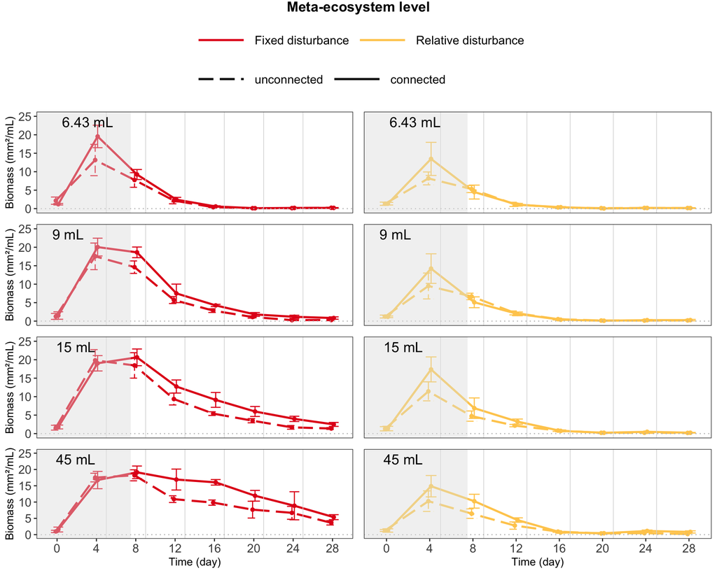

```r
# --- PLOT ONE PLOT PER ECOSYSTEM SIZE --- #

plot.metaecos.sizes.one.by.one.means(ds_metaecosystems,
                                     response_variable_selected,
                                     y_upper_limit,
                                     legend_row_n_selected = 1,
                                     y_lower_limit) +
  ggtitle("Meta-ecosystem level") +
  theme(plot.title = element_text(size = plot_title_size,
                                  face = plot_title_face,
                                  hjust = plot_title_hjust))
```

**Log transformed**

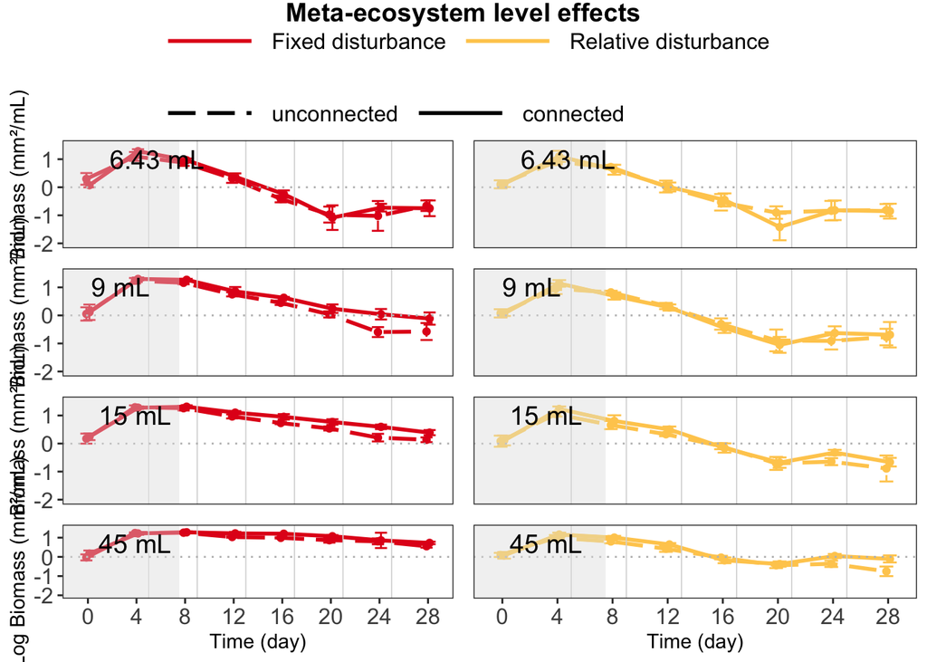

```r
plot.metaecos.sizes.one.by.one.means(ds_metaecosystems,
                                     paste0("log10_", response_variable_selected),
                                     y_upper_limit = 1.5,
                                     legend_row_n_selected = 1,
                                     y_lower_limit = -2) +
  ggtitle("Meta-ecosystem level effects") +
  theme(plot.title = element_text(size = plot_title_size,
                                  face = plot_title_face,
                                  hjust = plot_title_hjust))
```

**Effect sizes**

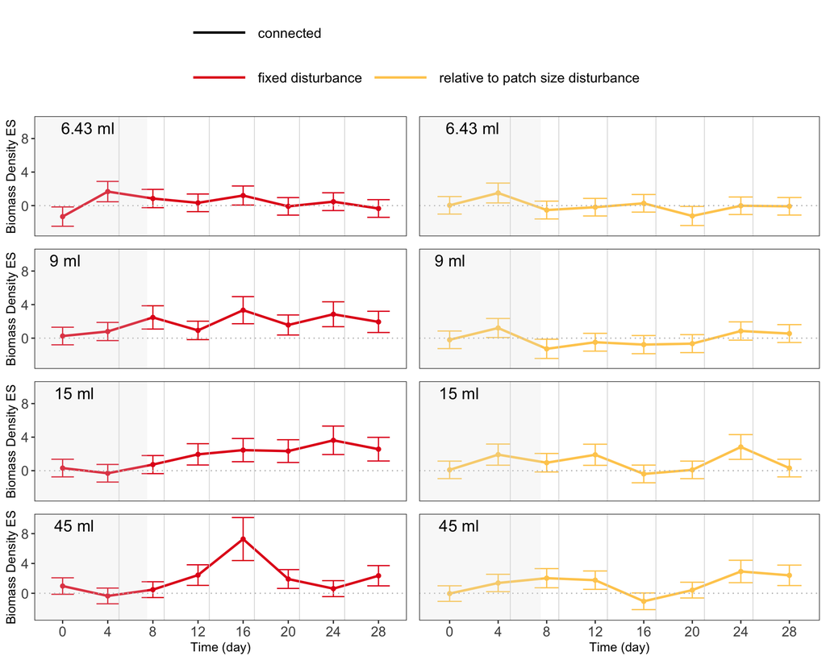

```r
plot.metaecos.sizes.one.by.one.es(ds_metaecosystems_effect_size,
                                  response_variable_selected,
                                  y_upper_limit = 10,
                                  legend_row_n_selected = 1,
                                  y_lower_limit = -3)
```

**Prepare & plot data for analysis**

```r
# --- PREPARE DATA FOR ANALYSIS --- #

# Add baselines

baseline = ds_metaecosystems %>%
  filter(time_point == time_point_of_baselines) %>%
  select(metaecosystem_ID,
         all_of(response_variable_selected)) %>%
  rename(baseline = all_of(response_variable_selected))

data_for_analysis = ds_metaecosystems %>%
  left_join(baseline)

# Filter and mutate

data_for_analysis = data_for_analysis %>%
  filter(time_point %in% time_points_model,
         !is.na(!!sym(response_variable_selected)),
         connection == "connected" |
          ecosystems_combined %in% unconnected_metaecosystems_selected) %>%
  mutate(conn = factor(x = ifelse(connection == "connected",
                                  "con",
                                  "unconnected"),
                       levels = c("unconnected", "con")))
```

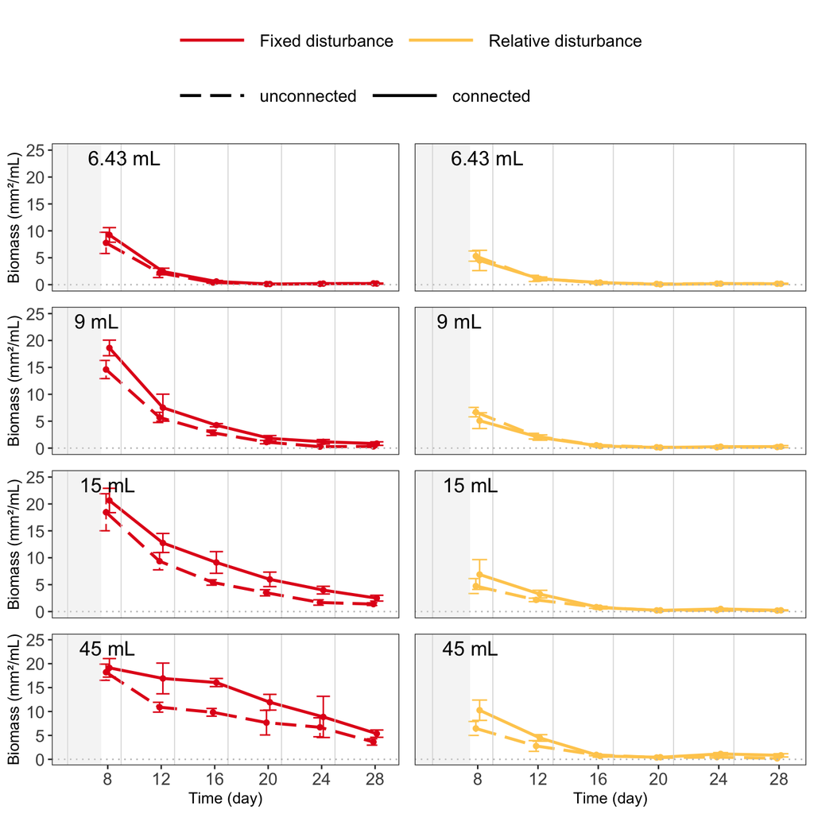

```r
# --- PLOT ONE PLOT PER ECOSYSTEM SIZE --- #

plot.metaecos.sizes.one.by.one.means(data_for_analysis,
                                     response_variable_selected,
                                     y_upper_limit = 25)
```

**Create model**

```r
# --- CREATE MODEL --- #

# Prepare data

data_for_analysis = data_for_analysis %>%
  rename(size = ecosystem_size_ml,
         disturb_type = volume_disturbed_across_sizes) %>%
  mutate(size = as.factor(size),
         day = as.factor(day))

# Define formula

formula <- as.formula(paste(response_variable_selected,
                            "~",
                            "size * conn * disturb_type +",
                            "(1 | time_point) +",
                            "(1 | baseline)")) %>%
  print()
```

```
## bioarea_mm2_per_ml ~ size * conn * disturb_type + (1 | time_point) +
##     (1 | baseline)
```

```r
# Create model

model <- glmmTMB(formula,
                 data = data_for_analysis,
                 family = tweedie(link = "log"),
                 dispformula = ~ bioarea_mm2_per_ml)
car::Anova(model, type = "III")
```

```
## Analysis of Deviance Table (Type III Wald chisquare tests)
##
## Response: bioarea_mm2_per_ml
##                           Chisq Df Pr(>Chisq)
## (Intercept)              1.0304  1   0.310062
## size                   581.5836  3  < 2.2e-16 ***
## conn                     1.2362  1   0.266207
## disturb_type             4.5062  1   0.033771 *
## size:conn                9.6967  3   0.021328 *
## size:disturb_type      196.2214  3  < 2.2e-16 ***
## conn:disturb_type        2.1791  1   0.139900
## size:conn:disturb_type  14.0772  3   0.002802 **
## ---
## Signif. codes:  0 '***' 0.001 '**' 0.01 '*' 0.05 '.' 0.1 ' ' 1
```

```r
# --- SHOW MODEL SUMMARY --- #

print(summary(model), digits = 3)
```

```
##  Family: tweedie  ( log )
## Formula:
## bioarea_mm2_per_ml ~ size * conn * disturb_type + (1 | time_point) +
##     (1 | baseline)
## Dispersion:                          ~bioarea_mm2_per_ml
## Data: data_for_analysis
##
##       AIC       BIC    logLik -2*log(L)  df.resid
##    1365.9    1457.3    -661.9    1323.9       555
##
## Random effects:
##
## Conditional model:
##  Groups     Name        Variance Std.Dev.
##  time_point (Intercept) 1.33e+00 1.15e+00
##  baseline   (Intercept) 9.09e-11 9.53e-06
## Number of obs: 576, groups:  time_point, 6; baseline, 96
##
## Conditional model:
##                                     Estimate Std. Error z value Pr(>|z|)
## (Intercept)                          -0.4864     0.4792   -1.02   0.3101
## size9                                 1.1204     0.1174    9.55  < 2e-16 ***
## size15                                2.0767     0.1176   17.66  < 2e-16 ***
## size45                                2.8113     0.1233   22.80  < 2e-16 ***
## conncon                               0.1345     0.1210    1.11   0.2662
## disturb_typerelative                 -0.2584     0.1217   -2.12   0.0338 *
## size9:conncon                         0.4229     0.1632    2.59   0.0096 **
## size15:conncon                        0.4342     0.1626    2.67   0.0076 **
## size45:conncon                        0.1813     0.1731    1.05   0.2950
## size9:disturb_typerelative           -0.8258     0.1686   -4.90  9.6e-07 ***
## size15:disturb_typerelative          -1.7240     0.1656  -10.41  < 2e-16 ***
## size45:disturb_typerelative          -2.1492     0.1676  -12.82  < 2e-16 ***
## conncon:disturb_typerelative         -0.2541     0.1722   -1.48   0.1399
## size9:conncon:disturb_typerelative   -0.3752     0.2355   -1.59   0.1111
## size15:conncon:disturb_typerelative  -0.0486     0.2330   -0.21   0.8348
## size45:conncon:disturb_typerelative   0.4815     0.2380    2.02   0.0431 *
## ---
## Signif. codes:  0 '***' 0.001 '**' 0.01 '*' 0.05 '.' 0.1 ' ' 1
##
## Dispersion model:
##                    Estimate Std. Error z value Pr(>|z|)
## (Intercept)         -1.8126     0.0935  -19.40  < 2e-16 ***
## bioarea_mm2_per_ml   0.1586     0.0201    7.89  3.1e-15 ***
## ---
## Signif. codes:  0 '***' 0.001 '**' 0.01 '*' 0.05 '.' 0.1 ' ' 1
```

```r
# --- CODE MODEL CONSTRASTS --- #

# Estimate marginal means (least-squares means)

emmeans_output = emmeans(model,
                         specs = ~  conn * disturb_type * size,
                         adjust = "sidak",
                         lmer.df = "satterthwaite")

emmeans_output
```

```
##  conn        disturb_type size  emmean    SE  df asymp.LCL asymp.UCL
##  unconnected fixed        6.43 -0.4864 0.479 Inf    -1.899     0.926
##  con         fixed        6.43 -0.3520 0.479 Inf    -1.764     1.061
##  unconnected relative     6.43 -0.7448 0.479 Inf    -2.157     0.668
##  con         relative     6.43 -0.8645 0.479 Inf    -2.277     0.548
##  unconnected fixed        9     0.6340 0.478 Inf    -0.774     2.042
##  con         fixed        9     1.1914 0.477 Inf    -0.215     2.598
##  unconnected relative     9    -0.4502 0.479 Inf    -1.862     0.962
##  con         relative     9    -0.5222 0.478 Inf    -1.933     0.888
##  unconnected fixed        15    1.5903 0.477 Inf     0.184     2.997
##  con         fixed        15    2.1590 0.478 Inf     0.750     3.568
##  unconnected relative     15   -0.3921 0.478 Inf    -1.801     1.017
##  con         relative     15   -0.1261 0.478 Inf    -1.535     1.283
##  unconnected fixed        45    2.3248 0.478 Inf     0.915     3.735
##  con         fixed        45    2.6406 0.481 Inf     1.222     4.059
##  unconnected relative     45   -0.0827 0.478 Inf    -1.491     1.325
##  con         relative     45    0.4605 0.477 Inf    -0.946     1.867
##
## Results are given on the log (not the response) scale.
## Confidence level used: 0.95
## Conf-level adjustment: sidak method for 16 estimates
```

```r
# Give a name for each level which you want to compare

uncon_fixed_6_43 = c(1, rep(0,15))
con_fixed_6_43 = c(rep(0,1), 1, rep(0,14))
uncon_relative_6_43 = c(rep(0,2), 1, rep(0,13))
con_relative_6_43 = c(rep(0,3), 1, rep(0,12))
uncon_fixed_9 = c(rep(0,4), 1, rep(0,11))
con_fixed_9 = c(rep(0,5), 1, rep(0,10))
uncon_relative_9 = c(rep(0,6), 1, rep(0,9))
con_relative_9 = c(rep(0,7), 1, rep(0,8))
uncon_fixed_15 = c(rep(0,8), 1, rep(0,7))
con_fixed_15 = c(rep(0,9), 1, rep(0,6))
uncon_relative_15 = c(rep(0,10), 1, rep(0,5))
con_relative_15 = c(rep(0,11), 1, rep(0,4))
uncon_fixed_45 = c(rep(0,12), 1, rep(0,3))
con_fixed_45 = c(rep(0,13), 1, rep(0,2))
uncon_relative_45 = c(rep(0,14), 1, rep(0,1))
con_relative_45 = c(rep(0,15), 1)

# Compute the contrasts

contrasts = contrast(emmeans_output,
                     method = list("6.43 ml fixed" = con_fixed_6_43 - uncon_fixed_6_43,
                                   "9.00 ml fixed" = con_fixed_9 - uncon_fixed_9,
                                   "15.00 ml fixed" = con_fixed_15 - uncon_fixed_15,
                                   "45.00 ml fixed" = con_fixed_45 - uncon_fixed_45,
                                   "6.43 ml relative" = con_relative_6_43 - uncon_relative_6_43,
                                   "9.00 ml relative" = con_relative_9 - uncon_relative_9,
                                   "15.00 ml relative" = con_relative_15 - uncon_relative_15,
                                   "45.00 ml relative" = con_relative_45 - uncon_relative_45),
                     type = "response")

nested_contrasts <- contrast(contrasts,
                             method = list(
                               "Difference in effects at 6.43 ml" = c(1, 0, 0, 0, -1, 0, 0, 0),
                               "Difference in effects at 9.00 ml" = c(0, 1, 0, 0, 0, -1, 0, 0),
                               "Difference in effects at 15.00 ml" = c(0, 0, 1, 0, 0, 0, -1, 0),
                               "Difference in effects at 45.00 ml" = c(0, 0, 0, 1, 0, 0, 0, -1)))

# Tidy up contrasts

upper_CI = (confint(contrasts)$asymp.UCL - 1) * 100
lower_CI = (confint(contrasts)$asymp.LCL - 1) * 100

contrasts = contrasts %>%
  as.data.frame(.) %>%
  mutate(ratio = round(ratio, 2),
         percentage = (ratio-1)*100,
         SE = round(SE, 2),
         lower.CL = round(lower_CI, 2),  # Lower confidence limit
         upper.CL = round(upper_CI, 2),  # Upper confidence limit
         z.ratio = round(z.ratio, 2),
         p.value = round(p.value, 3)) %>%
  select(contrast,
         percentage,
         lower.CL,
         upper.CL,
         SE,
         z.ratio,
         p.value)

contrasts$" " <- ""
contrasts$" "[contrasts$p.value < 0.05] <- "*"
contrasts$" "[contrasts$p.value < 0.01] <- "**"
contrasts$" "[contrasts$p.value < 0.001] <- "***"

# Tidy up nested contrasts

upper_CI = (confint(nested_contrasts)$asymp.UCL - 1) * 100
lower_CI = (confint(nested_contrasts)$asymp.LCL - 1) * 100

nested_contrasts = nested_contrasts %>%
  as.data.frame(.) %>%
  mutate(ratio = round(ratio, 2),
         percentage = (ratio-1)*100,
         lower.CL = round(lower_CI, 2),  # Lower confidence limit
         upper.CL = round(upper_CI, 2),  # Upper confidence limit
         SE = round(SE, 2),
         z.ratio = round(z.ratio, 2),
         p.value = round(p.value, 3)) %>%
  select(contrast,
         percentage,
         lower.CL,
         upper.CL,
         SE,
         z.ratio,
         p.value)

nested_contrasts$" " <- ""
nested_contrasts$" "[nested_contrasts$p.value < 0.05] <- "*"
nested_contrasts$" "[nested_contrasts$p.value < 0.01] <- "**"
nested_contrasts$" "[nested_contrasts$p.value < 0.001] <- "***"
```

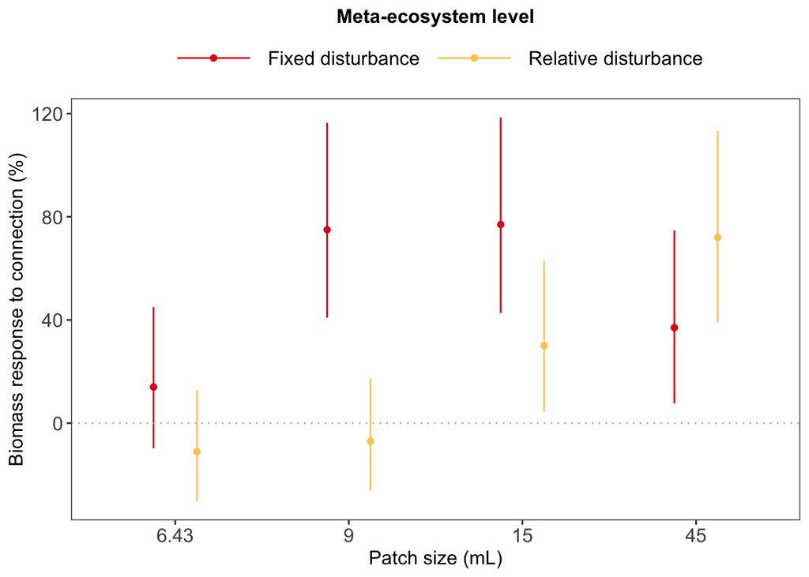

```r
plot.metaecos.contrasts(contrasts,
                        response_variable_selected)
```

**Model ANOVA**

```r
# --- SHOW MODEL ANOVA --- #

car::Anova(model, type = "III")
```

```
## Analysis of Deviance Table (Type III Wald chisquare tests)
##
## Response: bioarea_mm2_per_ml
##                           Chisq Df Pr(>Chisq)
## (Intercept)              1.0304  1   0.310062
## size                   581.5836  3  < 2.2e-16 ***
## conn                     1.2362  1   0.266207
## disturb_type             4.5062  1   0.033771 *
## size:conn                9.6967  3   0.021328 *
## size:disturb_type      196.2214  3  < 2.2e-16 ***
## conn:disturb_type        2.1791  1   0.139900
## size:conn:disturb_type  14.0772  3   0.002802 **
## ---
## Signif. codes:  0 '***' 0.001 '**' 0.01 '*' 0.05 '.' 0.1 ' ' 1
```

**Model contrasts**

```r
# --- SHOW MODEL CONTRASTS --- #

contrasts
```

```
##            contrast percentage lower.CL upper.CL   SE z.ratio p.value
## 1     6.43 ml fixed         14    -9.75    45.00 0.14    1.11   0.266
## 2     9.00 ml fixed         75    40.89   116.39 0.19    5.09   0.000 ***
## 3    15.00 ml fixed         77    42.72   118.53 0.19    5.23   0.000 ***
## 4    45.00 ml fixed         37     7.61    74.76 0.17    2.55   0.011   *
## 5  6.43 ml relative        -11   -30.22    12.80 0.11   -0.98   0.329
## 6  9.00 ml relative         -7   -26.22    17.36 0.11   -0.61   0.543
## 7 15.00 ml relative         30     4.51    62.89 0.15    2.35   0.019   *
## 8 45.00 ml relative         72    38.97   113.25 0.19    4.97   0.000 ***
```

```r
nested_contrasts
```

```
##                            contrast percentage lower.CL upper.CL   SE z.ratio
## 1  Difference in effects at 6.43 ml         29    -7.99    80.68 0.22    1.48
## 2  Difference in effects at 9.00 ml         88    36.92   157.15 0.30    3.91
## 3 Difference in effects at 15.00 ml         35    -0.49    84.10 0.21    1.93
## 4 Difference in effects at 45.00 ml        -20   -42.27     9.93 0.13   -1.38
##   p.value
## 1   0.140
## 2   0.000 ***
## 3   0.054
## 4   0.166
```

**Model residuals**

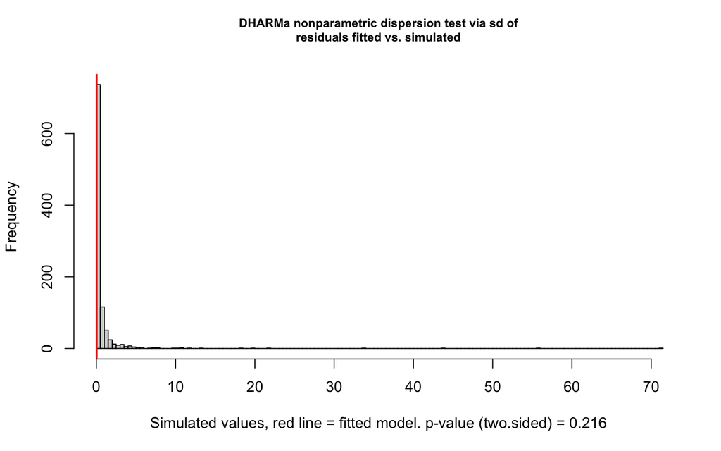

```
##
##  DHARMa nonparametric dispersion test via sd of residuals fitted vs.
##  simulated
##
## data:  simulationOutput
## dispersion = 0.04441, p-value = 0.216
## alternative hypothesis: two.sided
```

```r
# --- PLOT MODEL RESIDUALS --- #

# Simulate residuals from the fitted model

simulationOutput <- simulateResiduals(fittedModel = model,
                                      n = 1000)

# Test for overdispersion in the model to check if variance exceeds mean

testDispersion(simulationOutput)
```

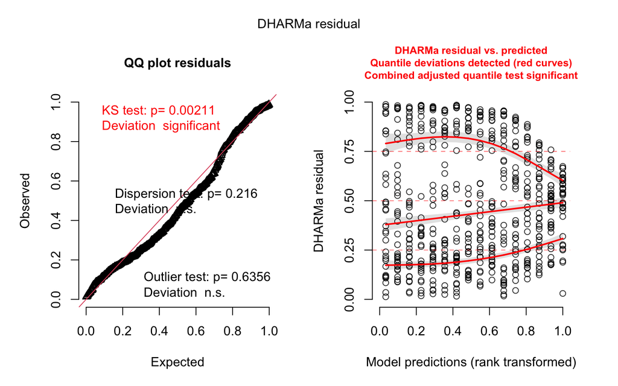

```r
# Plot Q-Q and Residuals vs Fitted plots

plot(simulationOutput)
```

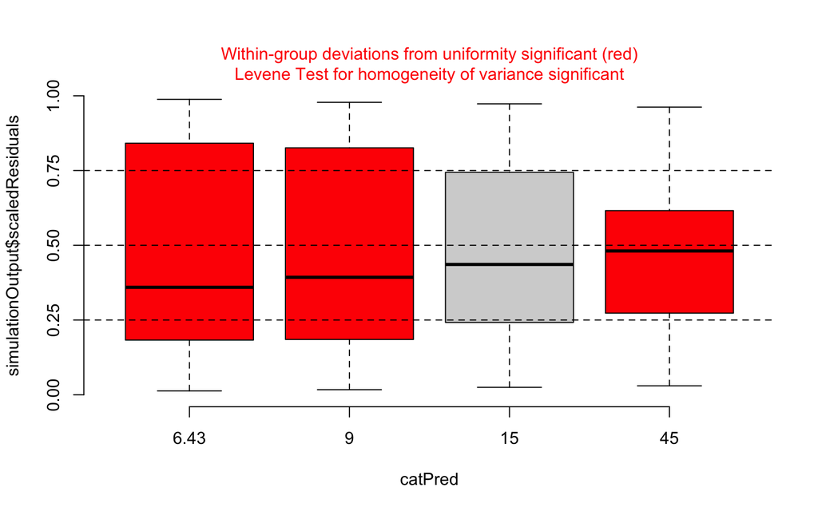

```r
# Plot residuals against specific predictors to check if residuals are
# independent of these variables - fixed variables

plotResiduals(simulationOutput,
              form = data_for_analysis$size)
```

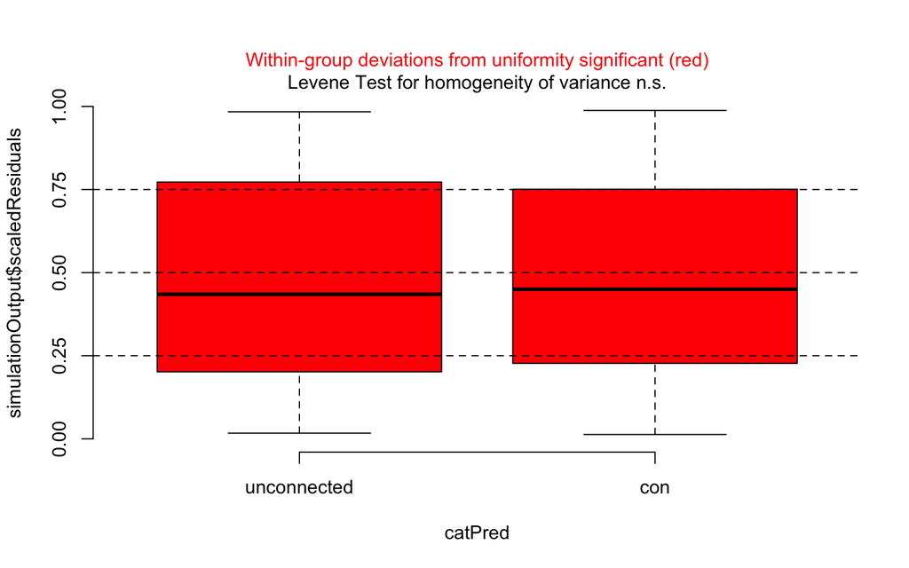

```r
plotResiduals(simulationOutput,
              form = data_for_analysis$conn)
```

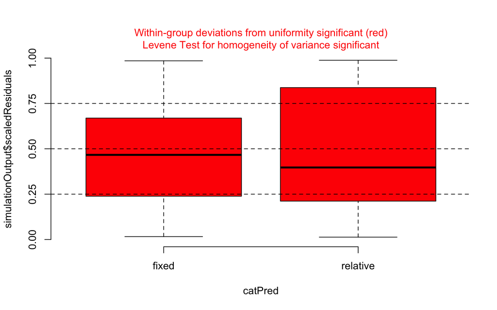

```r
plotResiduals(simulationOutput,
              form = data_for_analysis$disturb_type)
```

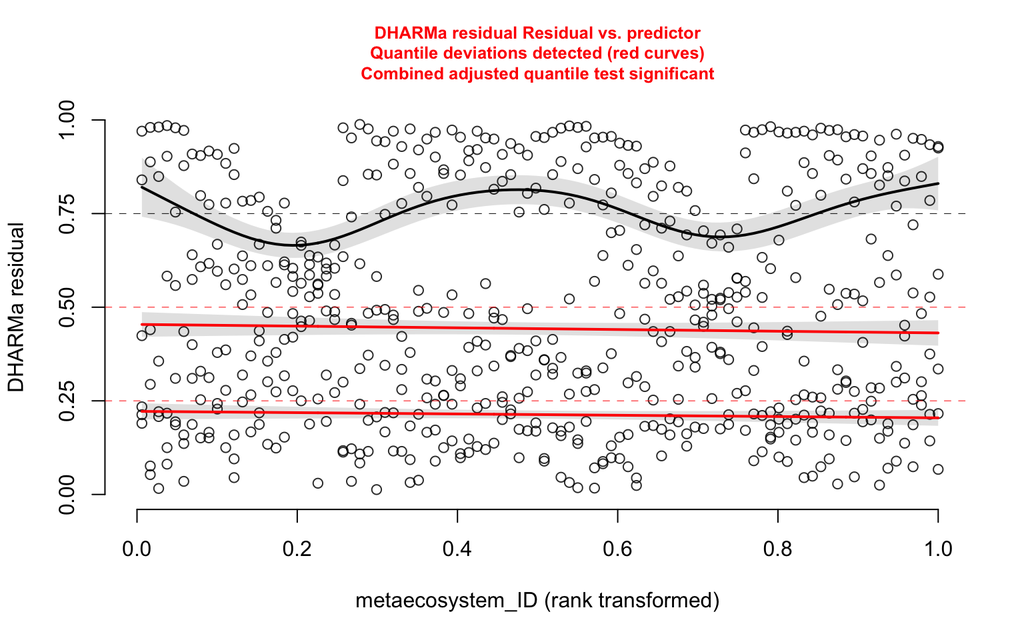

```r
# Plot residuals against specific predictors to check if residuals are
# independent of these variables - random variables

plotResiduals(simulationOutput,
              form = data_for_analysis$metaecosystem_ID)
```

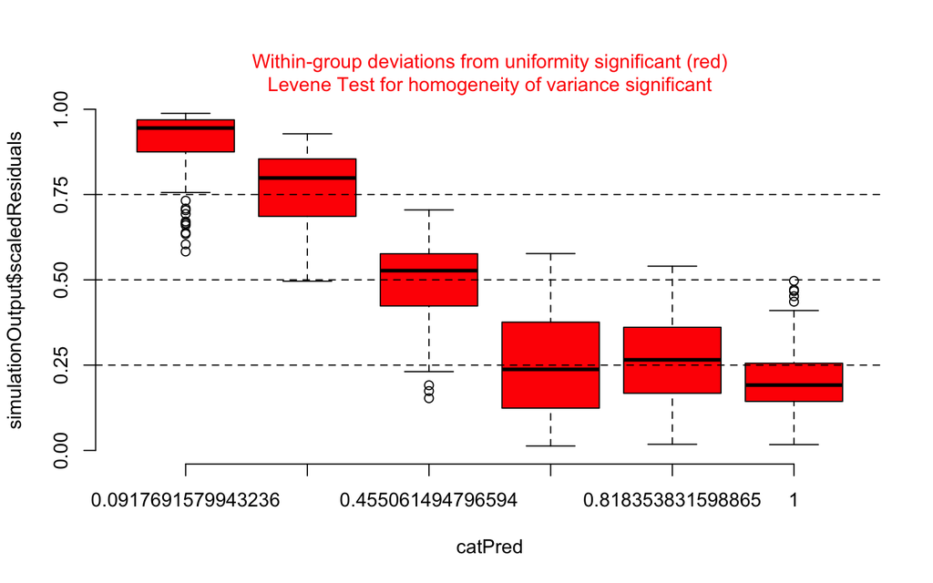

```r
plotResiduals(simulationOutput,
              form = data_for_analysis$time_point)
```

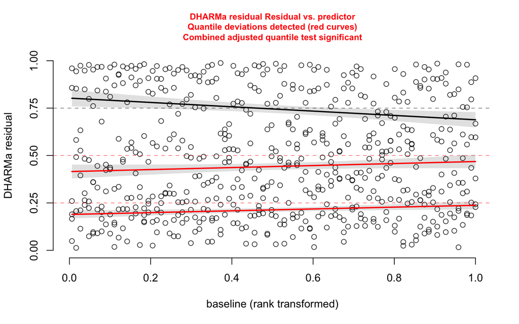

```r
plotResiduals(simulationOutput,
              form = data_for_analysis$baseline)
```

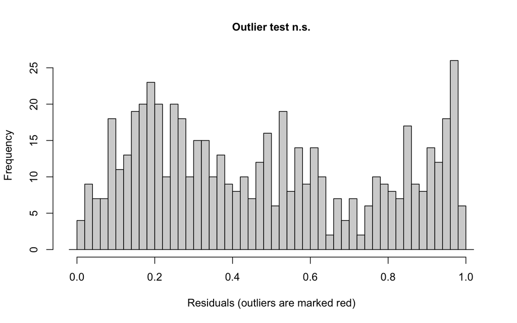

```
##
##  DHARMa outlier test based on exact binomial test with approximate
##  expectations
##
## data:  simulationOutput
## outliers at both margin(s) = 0, observations = 576, p-value = 0.6356
## alternative hypothesis: true probability of success is not equal to 0.001998002
## 95 percent confidence interval:
##  0.000000000 0.006383841
## sample estimates:
## frequency of outliers (expected: 0.001998001998002 )
##                                                    0
```

```r
# Test for outliers

testOutliers(simulationOutput)
```

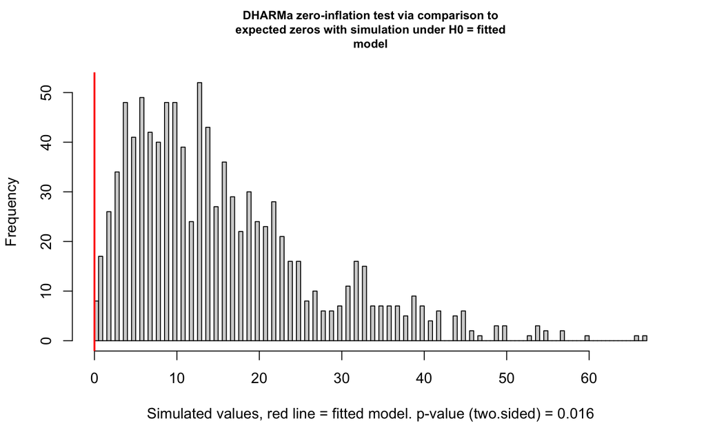

```
##
##  DHARMa zero-inflation test via comparison to expected zeros with
##  simulation under H0 = fitted model
##
## data:  simulationOutput
## ratioObsSim = 0, p-value = 0.016
## alternative hypothesis: two.sided
```

```r
# Test for zero inflation not accounted for

testZeroInflation(simulationOutput)
```

```r
# Save figure according to Ecosphere guidelines

p <- plot.metaecos.contrasts(contrasts,
                             response_variable_selected)

ggsave(
  filename = here("..", "3_results", "figures", "paper", "Meta-ecosystems.tiff"),
  plot = p,
  device = "tiff",
  width = 18,
  height = 12,
  units = "cm",
  dpi = 600,
  compression = "lzw"
)
```

#### Without the smallest patches (6.43 ml)

As the smallest patches at the fixed and relative disturbance had the same disturbance level, I rerun the analysis to see if it’s robust to taking off these patch sizes.

```r
ds_metaecosystems_without_6.43 = ds_metaecosystems %>%
  filter(ecosystem_size_ml != 6.43)
```

**Prepare & plot data for analysis**

```r
# --- PREPARE DATA FOR ANALYSIS --- #

# Add baselines

baseline = ds_metaecosystems_without_6.43 %>%
  filter(time_point == time_point_of_baselines) %>%
  select(metaecosystem_ID,
         all_of(response_variable_selected)) %>%
  rename(baseline = all_of(response_variable_selected))

data_for_analysis = ds_metaecosystems_without_6.43 %>%
  left_join(baseline)

# Filter and mutate

data_for_analysis = data_for_analysis %>%
  filter(time_point %in% time_points_model,
         !is.na(!!sym(response_variable_selected)),
         connection == "connected" |
          ecosystems_combined %in% unconnected_metaecosystems_selected) %>%
  mutate(conn = factor(x = ifelse(connection == "connected",
                                  "con",
                                  "unconnected"),
                       levels = c("unconnected", "con")))
```

**Create model**

```r
# --- CREATE MODEL --- #

# Prepare data

data_for_analysis = data_for_analysis %>%
  rename(size = ecosystem_size_ml,
         disturb_type = volume_disturbed_across_sizes) %>%
  mutate(size = as.factor(size),
         day = as.factor(day))

# Define formula

formula <- as.formula(paste(response_variable_selected,
                            "~",
                            "size * conn * disturb_type +",
                            "(1 | time_point) +",
                            "(1 | baseline)")) %>%
  print()
```

```
## bioarea_mm2_per_ml ~ size * conn * disturb_type + (1 | time_point) +
##     (1 | baseline)
```

```r
# Create model

model <- glmmTMB(formula,
                 data = data_for_analysis,
                 family = tweedie(link = "log"),
                 dispformula = ~ bioarea_mm2_per_ml)
car::Anova(model, type = "III")
```

```
## Analysis of Deviance Table (Type III Wald chisquare tests)
##
## Response: bioarea_mm2_per_ml
##                           Chisq Df Pr(>Chisq)
## (Intercept)              2.2063  1  0.1374517
## size                   202.9934  2  < 2.2e-16 ***
## conn                    22.7667  1  1.829e-06 ***
## disturb_type            75.1867  1  < 2.2e-16 ***
## size:conn                2.2773  2  0.3202501
## size:disturb_type       67.4144  2  2.297e-15 ***
## conn:disturb_type       13.9465  1  0.0001881 ***
## size:conn:disturb_type  12.2972  2  0.0021364 **
## ---
## Signif. codes:  0 '***' 0.001 '**' 0.01 '*' 0.05 '.' 0.1 ' ' 1
```

```r
# --- SHOW MODEL SUMMARY --- #

print(summary(model), digits = 3)
```

```
##  Family: tweedie  ( log )
## Formula:
## bioarea_mm2_per_ml ~ size * conn * disturb_type + (1 | time_point) +
##     (1 | baseline)
## Dispersion:                          ~bioarea_mm2_per_ml
## Data: data_for_analysis
##
##       AIC       BIC    logLik -2*log(L)  df.resid
##    1299.3    1368.4    -632.6    1265.3       415
##
## Random effects:
##
## Conditional model:
##  Groups     Name        Variance Std.Dev.
##  time_point (Intercept) 1.06e+00 1.03e+00
##  baseline   (Intercept) 9.34e-11 9.66e-06
## Number of obs: 432, groups:  time_point, 6; baseline, 72
##
## Conditional model:
##                                     Estimate Std. Error z value Pr(>|z|)
## (Intercept)                           0.6364     0.4285    1.49  0.13745
## size15                                0.8948     0.1085    8.25  < 2e-16 ***
## size45                                1.6133     0.1133   14.24  < 2e-16 ***
## conncon                               0.5163     0.1082    4.77  1.8e-06 ***
## disturb_typerelative                 -1.0096     0.1164   -8.67  < 2e-16 ***
## size15:conncon                        0.0356     0.1493    0.24  0.81150
## size45:conncon                       -0.1835     0.1559   -1.18  0.23931
## size15:disturb_typerelative          -0.8628     0.1587   -5.44  5.4e-08 ***
## size45:disturb_typerelative          -1.2892     0.1591   -8.10  5.4e-16 ***
## conncon:disturb_typerelative         -0.5984     0.1602   -3.73  0.00019 ***
## size15:conncon:disturb_typerelative   0.3081     0.2223    1.39  0.16568
## size45:conncon:disturb_typerelative   0.7789     0.2241    3.48  0.00051 ***
## ---
## Signif. codes:  0 '***' 0.001 '**' 0.01 '*' 0.05 '.' 0.1 ' ' 1
##
## Dispersion model:
##                    Estimate Std. Error z value Pr(>|z|)
## (Intercept)         -1.7363     0.1086  -15.99  < 2e-16 ***
## bioarea_mm2_per_ml   0.1346     0.0261    5.15  2.6e-07 ***
## ---
## Signif. codes:  0 '***' 0.001 '**' 0.01 '*' 0.05 '.' 0.1 ' ' 1
```

```r
# --- CODE MODEL CONSTRASTS --- #

# Estimate marginal means (least-squares means)

emmeans_output = emmeans(model,
                         specs = ~  conn * disturb_type * size,
                         adjust = "sidak",
                         lmer.df = "satterthwaite")

emmeans_output
```

```
##  conn        disturb_type size  emmean    SE  df asymp.LCL asymp.UCL
##  unconnected fixed        9     0.6364 0.428 Inf   -0.5881     1.861
##  con         fixed        9     1.1528 0.428 Inf   -0.0695     2.375
##  unconnected relative     9    -0.3731 0.431 Inf   -1.6035     0.857
##  con         relative     9    -0.4552 0.430 Inf   -1.6836     0.773
##  unconnected fixed        15    1.5313 0.427 Inf    0.3097     2.753
##  con         fixed        15    2.0832 0.428 Inf    0.8599     3.307
##  unconnected relative     15   -0.3411 0.429 Inf   -1.5681     0.886
##  con         relative     15   -0.0794 0.429 Inf   -1.3054     1.147
##  unconnected fixed        45    2.2497 0.428 Inf    1.0258     3.474
##  con         fixed        45    2.5826 0.431 Inf    1.3522     3.813
##  unconnected relative     45   -0.0491 0.429 Inf   -1.2741     1.176
##  con         relative     45    0.4643 0.428 Inf   -0.7590     1.688
##
## Results are given on the log (not the response) scale.
## Confidence level used: 0.95
## Conf-level adjustment: sidak method for 12 estimates
```

```r
# Give a name for each level which you want to compare

uncon_fixed_9 = c(1, rep(0,11))
con_fixed_9 = c(rep(0,1), 1, rep(0,10))
uncon_relative_9 = c(rep(0,2), 1, rep(0,9))
con_relative_9 = c(rep(0,3), 1, rep(0,8))
uncon_fixed_15 = c(rep(0,4), 1, rep(0,7))
con_fixed_15 = c(rep(0,5), 1, rep(0,6))
uncon_relative_15 = c(rep(0,6), 1, rep(0,5))
con_relative_15 = c(rep(0,7), 1, rep(0,4))
uncon_fixed_45 = c(rep(0,8), 1, rep(0,3))
con_fixed_45 = c(rep(0,9), 1, rep(0,2))
uncon_relative_45 = c(rep(0,10), 1, rep(0,1))
con_relative_45 = c(rep(0,11), 1)

# Compute the contrasts

contrasts = contrast(emmeans_output,
                     method = list("9.00 ml fixed" = con_fixed_9 - uncon_fixed_9,
                                   "15.00 ml fixed" = con_fixed_15 - uncon_fixed_15,
                                   "45.00 ml fixed" = con_fixed_45 - uncon_fixed_45,
                                   "9.00 ml relative" = con_relative_9 - uncon_relative_9,
                                   "15.00 ml relative" = con_relative_15 - uncon_relative_15,
                                   "45.00 ml relative" = con_relative_45 - uncon_relative_45),
                     type = "response")

nested_contrasts <- contrast(contrasts,
                             method = list(
                               "Difference in effects at 9.00 ml" = c(1, 0, 0, -1, 0, 0),
                               "Difference in effects at 15.00 ml" = c(0, 1, 0, 0, -1, 0),
                               "Difference in effects at 45.00 ml" = c(0, 0, 1, 0, 0, -1)))

# Tidy up contrasts

upper_CI = (confint(contrasts)$asymp.UCL - 1) * 100
lower_CI = (confint(contrasts)$asymp.LCL - 1) * 100

contrasts = contrasts %>%
  as.data.frame(.) %>%
  mutate(ratio = round(ratio, 2),
         percentage = (ratio-1)*100,
         SE = round(SE, 2),
         lower.CL = round(lower_CI, 2),  # Lower confidence limit
         upper.CL = round(upper_CI, 2),  # Upper confidence limit
         z.ratio = round(z.ratio, 2),
         p.value = round(p.value, 3)) %>%
  select(contrast,
         percentage,
         lower.CL,
         upper.CL,
         SE,
         z.ratio,
         p.value)

contrasts$" " <- ""
contrasts$" "[contrasts$p.value < 0.05] <- "*"
contrasts$" "[contrasts$p.value < 0.01] <- "**"
contrasts$" "[contrasts$p.value < 0.001] <- "***"

# Tidy up nested contrasts

upper_CI = (confint(nested_contrasts)$asymp.UCL - 1) * 100
lower_CI = (confint(nested_contrasts)$asymp.LCL - 1) * 100

nested_contrasts = nested_contrasts %>%
  as.data.frame(.) %>%
  mutate(ratio = round(ratio, 2),
         percentage = (ratio-1)*100,
         lower.CL = round(lower_CI, 2),  # Lower confidence limit
         upper.CL = round(upper_CI, 2),  # Upper confidence limit
         SE = round(SE, 2),
         z.ratio = round(z.ratio, 2),
         p.value = round(p.value, 3)) %>%
  select(contrast,
         percentage,
         lower.CL,
         upper.CL,
         SE,
         z.ratio,
         p.value)

nested_contrasts$" " <- ""
nested_contrasts$" "[nested_contrasts$p.value < 0.05] <- "*"
nested_contrasts$" "[nested_contrasts$p.value < 0.01] <- "**"
nested_contrasts$" "[nested_contrasts$p.value < 0.001] <- "***"
```

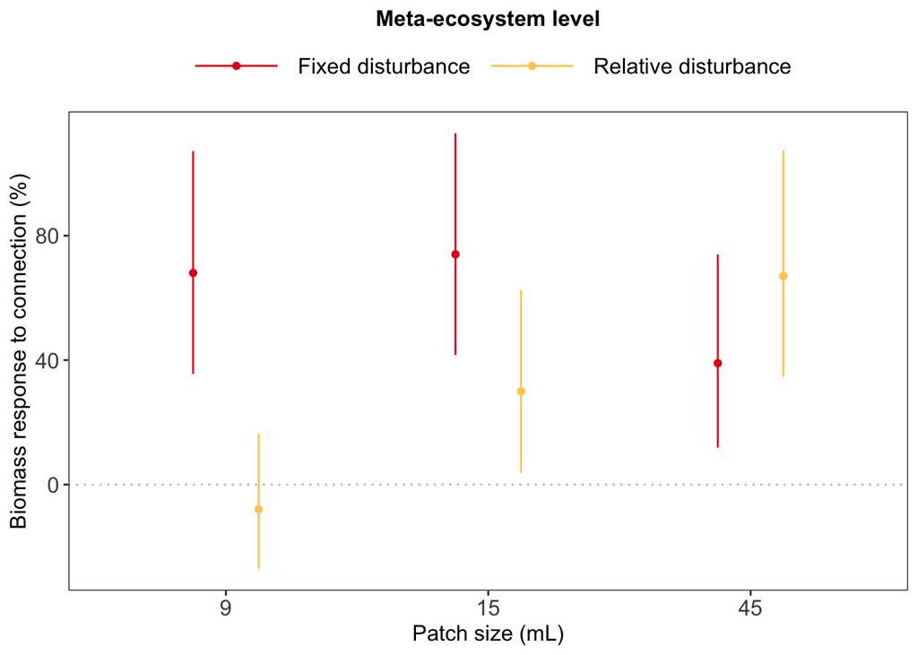

```r
plot.metaecos.contrasts(contrasts,
                        response_variable_selected)
```

**Model ANOVA**

```r
# --- SHOW MODEL ANOVA --- #

car::Anova(model, type = "III")
```

```
## Analysis of Deviance Table (Type III Wald chisquare tests)
##
## Response: bioarea_mm2_per_ml
##                           Chisq Df Pr(>Chisq)
## (Intercept)              2.2063  1  0.1374517
## size                   202.9934  2  < 2.2e-16 ***
## conn                    22.7667  1  1.829e-06 ***
## disturb_type            75.1867  1  < 2.2e-16 ***
## size:conn                2.2773  2  0.3202501
## size:disturb_type       67.4144  2  2.297e-15 ***
## conn:disturb_type       13.9465  1  0.0001881 ***
## size:conn:disturb_type  12.2972  2  0.0021364 **
## ---
## Signif. codes:  0 '***' 0.001 '**' 0.01 '*' 0.05 '.' 0.1 ' ' 1
```

**Model contrasts**

```r
# --- SHOW MODEL CONTRASTS --- #

contrasts
```

```
##            contrast percentage lower.CL upper.CL   SE z.ratio p.value
## 1     9.00 ml fixed         68    35.56   107.19 0.18    4.77   0.000 ***
## 2    15.00 ml fixed         74    41.65   112.92 0.18    5.31   0.000 ***
## 3    45.00 ml fixed         39    11.88    73.94 0.16    2.96   0.003  **
## 4  9.00 ml relative         -8   -27.09    16.41 0.11   -0.69   0.492
## 5 15.00 ml relative         30     3.82    62.56 0.15    2.29   0.022   *
## 6 45.00 ml relative         67    34.53   107.53 0.18    4.64   0.000 ***
```

```r
nested_contrasts
```

```
##                            contrast percentage lower.CL upper.CL   SE z.ratio
## 1  Difference in effects at 9.00 ml         82    32.89   149.04 0.29    3.73
## 2 Difference in effects at 15.00 ml         34    -1.30    81.04 0.21    1.88
## 3 Difference in effects at 45.00 ml        -17   -38.54    13.41 0.13   -1.15
##   p.value
## 1   0.000 ***
## 2   0.061
## 3   0.248
```

**Model residuals**

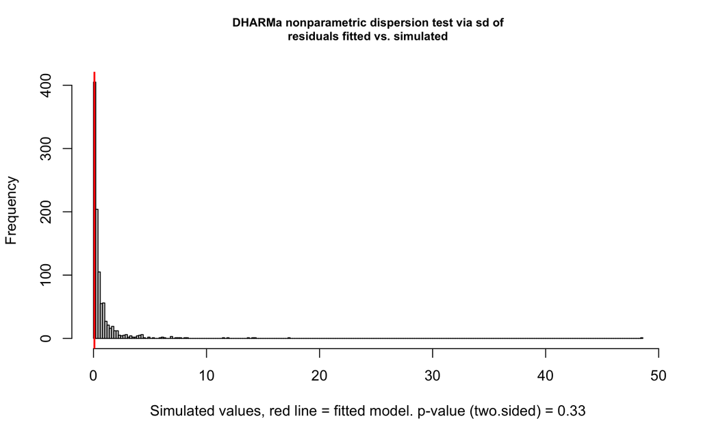

```
##
##  DHARMa nonparametric dispersion test via sd of residuals fitted vs.
##  simulated
##
## data:  simulationOutput
## dispersion = 0.10499, p-value = 0.33
## alternative hypothesis: two.sided
```

```r
# --- PLOT MODEL RESIDUALS --- #

# Simulate residuals from the fitted model

simulationOutput <- simulateResiduals(fittedModel = model,
                                      n = 1000)

# Test for overdispersion in the model to check if variance exceeds mean

testDispersion(simulationOutput)
```

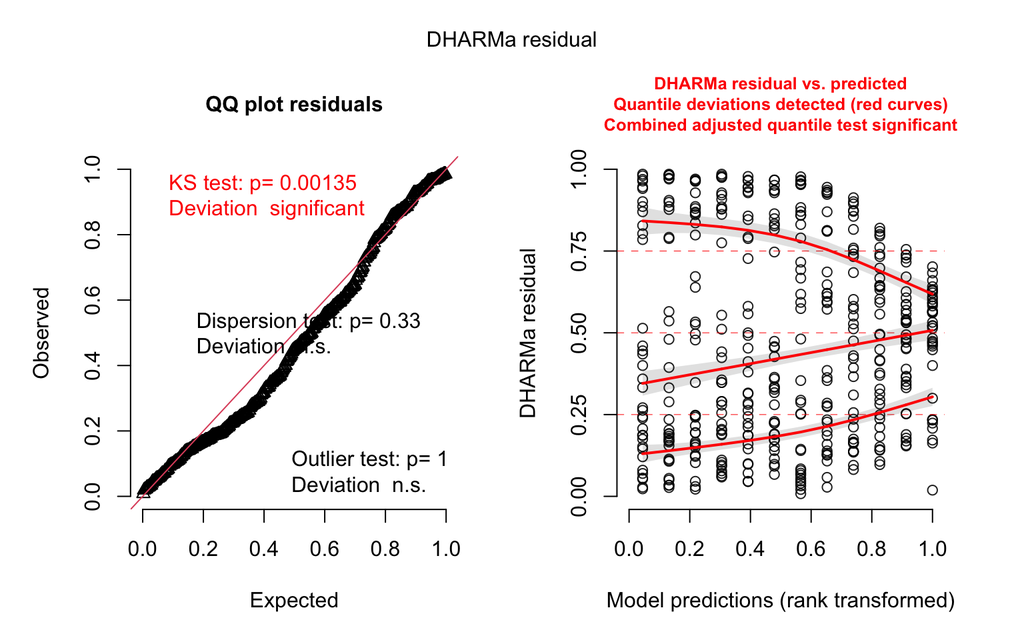

```r
# Plot Q-Q and Residuals vs Fitted plots

plot(simulationOutput)
```

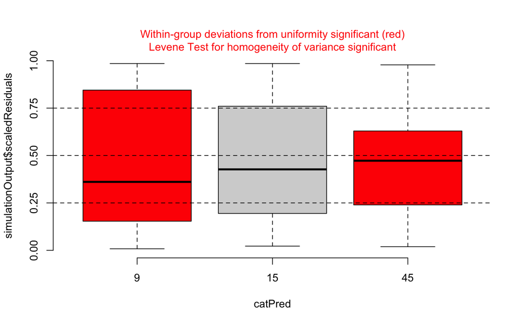

```r
# Plot residuals against specific predictors to check if residuals are
# independent of these variables - fixed variables

plotResiduals(simulationOutput,
              form = data_for_analysis$size)
```

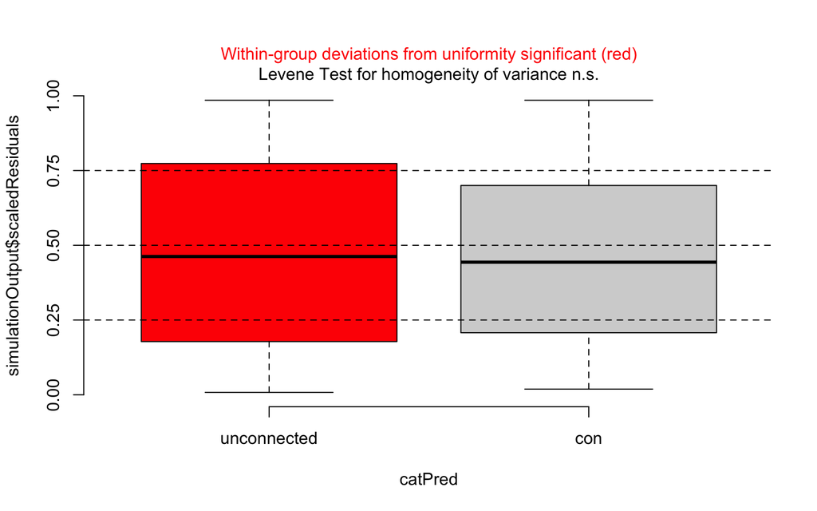

```r
plotResiduals(simulationOutput,
              form = data_for_analysis$conn)
```

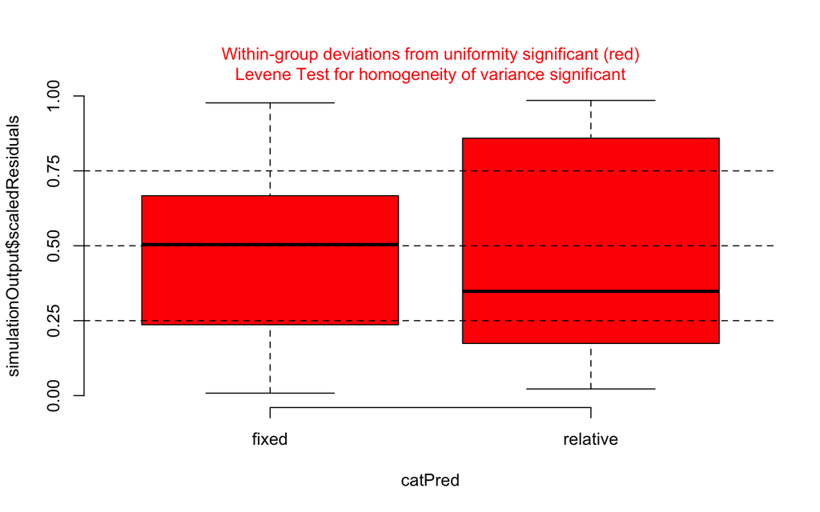

```r
plotResiduals(simulationOutput,
              form = data_for_analysis$disturb_type)
```

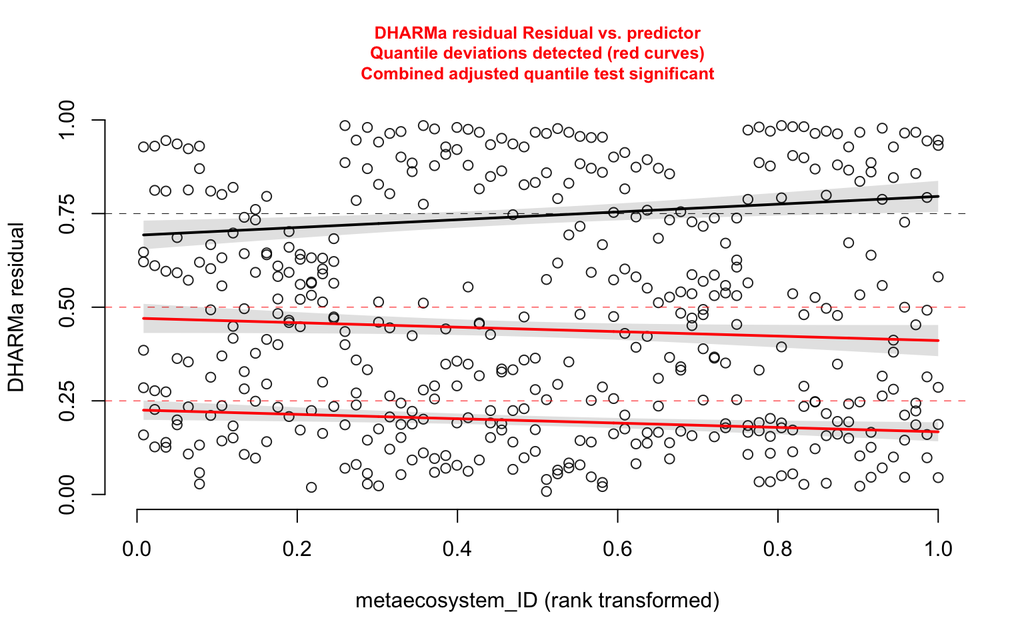

```r
# Plot residuals against specific predictors to check if residuals are
# independent of these variables - random variables

plotResiduals(simulationOutput,
              form = data_for_analysis$metaecosystem_ID)
```

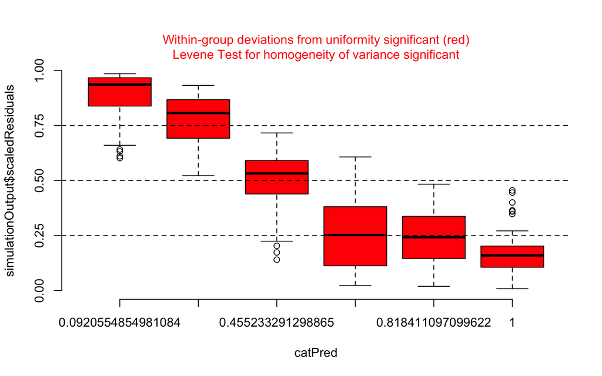

```r
plotResiduals(simulationOutput,
              form = data_for_analysis$time_point)
```

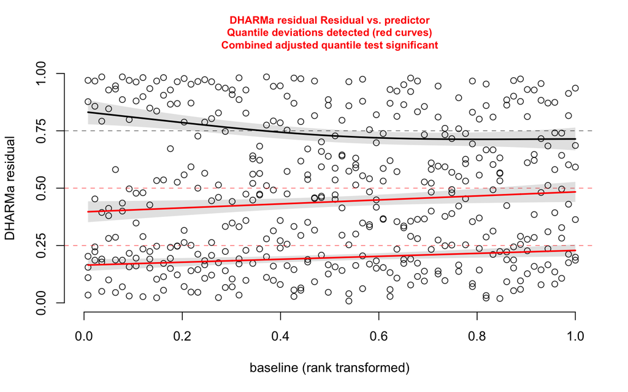

```r
plotResiduals(simulationOutput,
              form = data_for_analysis$baseline)
```

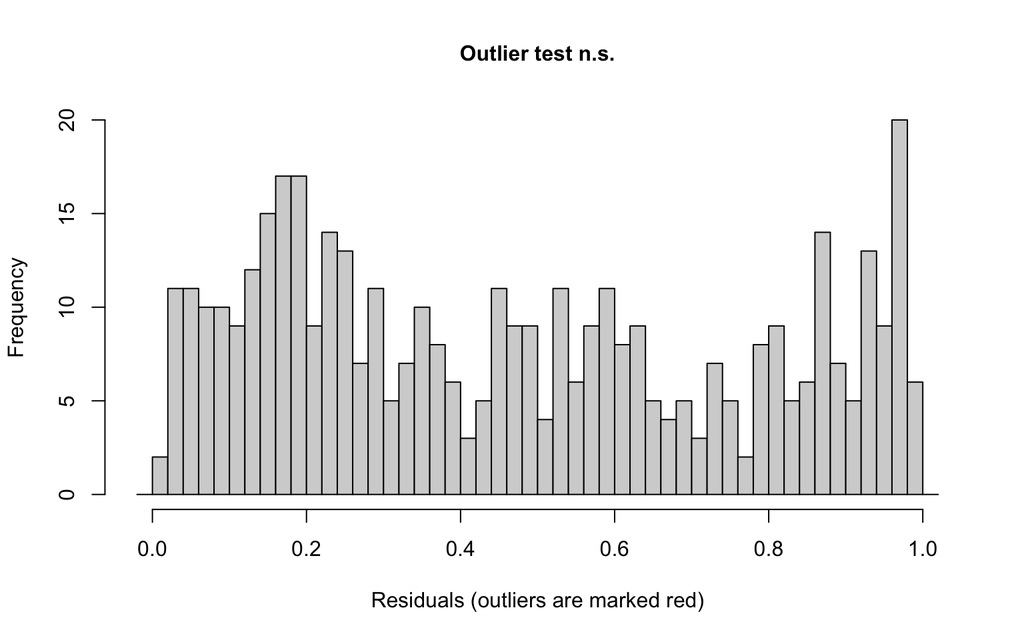

```
##
##  DHARMa outlier test based on exact binomial test with approximate
##  expectations
##
## data:  simulationOutput
## outliers at both margin(s) = 0, observations = 432, p-value = 1
## alternative hypothesis: true probability of success is not equal to 0.001998002
## 95 percent confidence interval:
##  0.000000000 0.008502718
## sample estimates:
## frequency of outliers (expected: 0.001998001998002 )
##                                                    0
```

```r
# Test for outliers

testOutliers(simulationOutput)
```

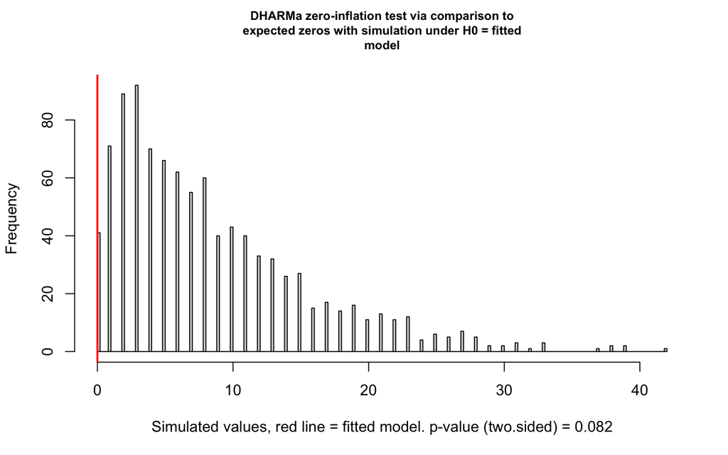

```
##
##  DHARMa zero-inflation test via comparison to expected zeros with
##  simulation under H0 = fitted model
##
## data:  simulationOutput
## ratioObsSim = 0, p-value = 0.082
## alternative hypothesis: two.sided
```

```r
# Test for zero inflation not accounted for

testZeroInflation(simulationOutput)
```

## Ecosystems

### Biomass

#### Autotrophic

```r
trophic_type_selected = "autotrophic"
```

```r
# --- DEFINE PARAMETERS --- #

response_variable_selected = "bioarea_mm2_per_ml"
```

**Original data**

```r
# --- PLOT ONE PLOT PER ECOSYSTEM SIZE --- #

# Plot heterotrophic ecosystems

if(trophic_type_selected == "heterotrophic"){

  system_type_to_print = "Heterotrophic ecosystems"

  plot = plot.ecos.sizes.one.by.one.means(ds_ecosystems,
                                          "heterotrophic",
                                          response_variable_selected,
                                          light_colour_hetero,
                                          dark_colour_hetero,
                                          y_upper_limit = 6.2) +
    ggtitle("Heterotrophic patch level") +
    theme(plot.title = element_text(size = plot_title_size,
                                    face = plot_title_face,
                                    hjust = plot_title_hjust))
}

if(trophic_type_selected == "autotrophic"){

  # Plot autotrophic ecosystems

  system_type_to_print = "Autotrophic ecosystems"

  plot = plot.ecos.sizes.one.by.one.means(ds_ecosystems,
                                          "autotrophic",
                                          response_variable_selected,
                                          light_colour_auto,
                                          dark_colour_auto,
                                          y_upper_limit = 48) +
    ggtitle("Autotrophic patch level") +
    theme(plot.title = element_text(size = plot_title_size,
                                    face = plot_title_face,
                                    hjust = plot_title_hjust))

}

system_type_to_print
```

```
## [1] "Autotrophic ecosystems"
```

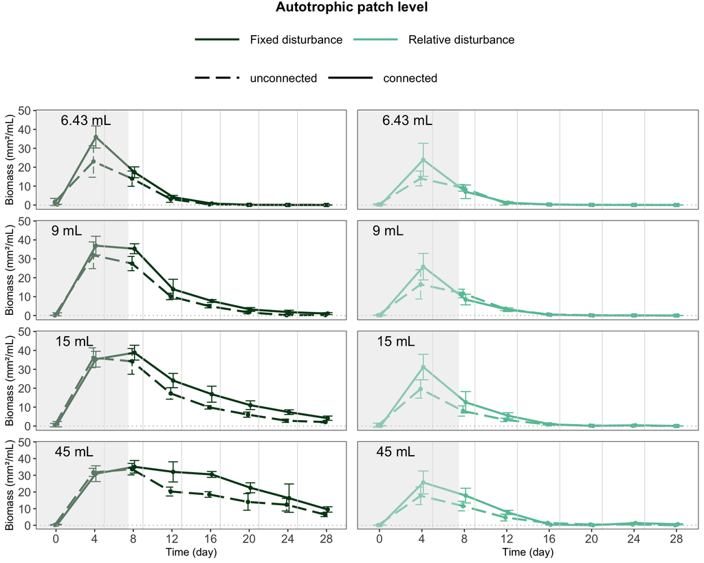

```r
plot
```

**Effect sizes**

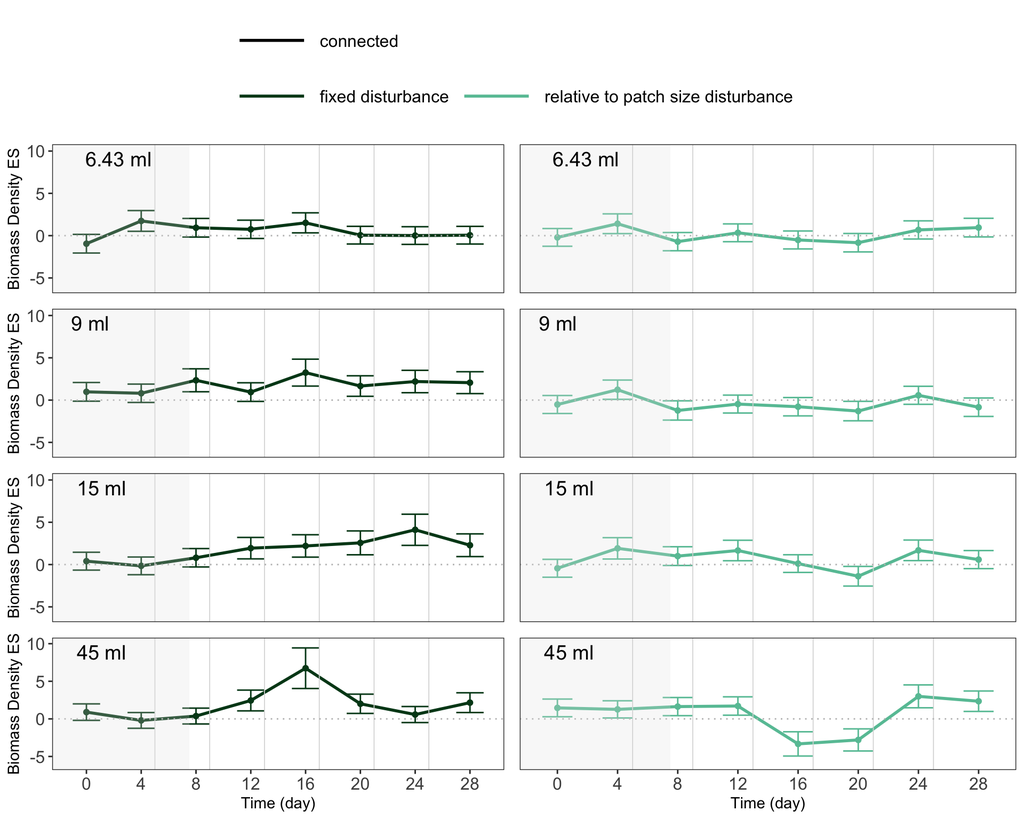

```r
if(trophic_type_selected == "heterotrophic"){
  plot.ecos.sizes.one.by.one.es(ds_ecosystems_effect_size,
                              trophic_type_selected,
                              response_variable_selected,
                              light_colour_hetero,
                              dark_colour_hetero,
                              y_upper_limit = 4,
                              legend_row_n_selected = 1,
                              y_lower_limit = -2)
}

if(trophic_type_selected == "autotrophic"){
  plot.ecos.sizes.one.by.one.es(ds_ecosystems_effect_size,
                              trophic_type_selected,
                              response_variable_selected,
                              light_colour_auto,
                              dark_colour_auto,
                              y_upper_limit = 10,
                              legend_row_n_selected = 1,
                              y_lower_limit = -6)
}
```

**Prepare & plot data for analysis**

```r
# --- PREPARE DATA FOR ANALYSIS --- #

# Add baselines

baseline = ds_ecosystems %>%
  filter(time_point == time_point_of_baselines) %>%
  select(ecosystem_ID,
         all_of(response_variable_selected)) %>%
  rename(baseline = all_of(response_variable_selected))

data_for_analysis = ds_ecosystems %>%
  left_join(baseline)

# Filter and mutate

data_for_analysis = data_for_analysis %>%
  filter(time_point %in% time_points_model,
         !is.na(!!sym(response_variable_selected)),
         trophic_type == trophic_type_selected) %>%
  mutate(trophic_type = as.factor(trophic_type),
         size = as.factor(ecosystem_size_ml),
         conn = factor(x = ifelse(connection == "connected",
                                  "con",
                                  "unconnected"),
                       levels = c("unconnected", "con")),
         volume_disturbed_across_sizes = as.factor(volume_disturbed_across_sizes),
         day = as.double(day),
         ecosystem_ID = as.factor(ecosystem_ID))
```

```
## [1] "Autotrophic ecosystems"
```

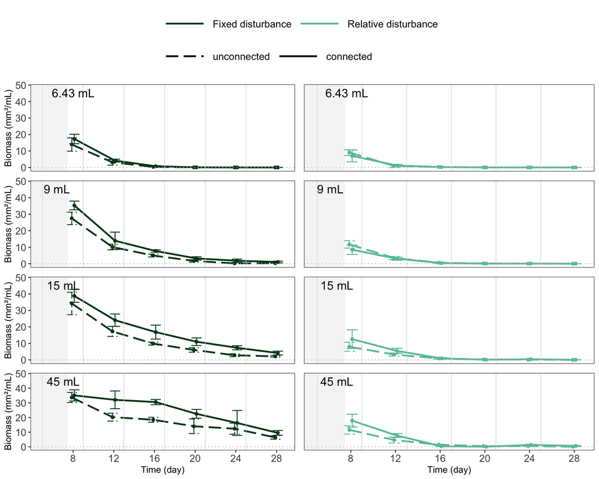

```r
# --- PLOT ONE PLOT PER ECOSYSTEM SIZE --- #

if(trophic_type_selected == "heterotrophic"){

  # Plot heterotrophic ecosystems

  print("Heterotrophic ecosystems")

  plot.ecos.sizes.one.by.one.means(data_for_analysis,
                                   "heterotrophic",
                                   response_variable_selected,
                                   light_colour_hetero,
                                   dark_colour_hetero,
                                   y_upper_limit = 6.2)

}

if(trophic_type_selected == "autotrophic"){

  # Plot autotrophic ecosystems

  print("Autotrophic ecosystems")

  plot.ecos.sizes.one.by.one.means(data_for_analysis,
                                   "autotrophic",
                                   response_variable_selected,
                                   light_colour_auto,
                                   dark_colour_auto,
                                   y_upper_limit = 48)
}
```

**Rename disturbance type**

```r
# Prepare data

data_for_analysis = data_for_analysis %>%
  rename(disturb_type = volume_disturbed_across_sizes)
```

**Create model**

```r
# --- CREATE MODEL --- #

# Create formula

formula = as.formula(paste("bioarea_mm2_per_ml ~",
                           "size * conn * disturb_type +",
                           "(1 | day) +",
                           "(1 | baseline)")) %>%
  print()
```

```
## bioarea_mm2_per_ml ~ size * conn * disturb_type + (1 | day) +
##     (1 | baseline)
```

```r
# Model

model <- glmmTMB(formula,
                 data = data_for_analysis,
                 family = tweedie(link = "log"),
                 dispformula = ~ bioarea_mm2_per_ml)
car::Anova(model, type = "III")
```

```
## Analysis of Deviance Table (Type III Wald chisquare tests)
##
## Response: bioarea_mm2_per_ml
##                           Chisq Df Pr(>Chisq)
## (Intercept)              0.9693  1   0.324865
## size                   417.9843  3  < 2.2e-16 ***
## conn                     2.5031  1   0.113624
## disturb_type             7.1590  1   0.007459 **
## size:conn                5.0084  3   0.171183
## size:disturb_type      113.9947  3  < 2.2e-16 ***
## conn:disturb_type        2.1987  1   0.138130
## size:conn:disturb_type  10.3970  3   0.015476 *
## ---
## Signif. codes:  0 '***' 0.001 '**' 0.01 '*' 0.05 '.' 0.1 ' ' 1
```

```r
# --- SHOW MODEL SUMMARY --- #

print(summary(model), digits = 3)
```

```
##  Family: tweedie  ( log )
## Formula:
## bioarea_mm2_per_ml ~ size * conn * disturb_type + (1 | day) +
##     (1 | baseline)
## Dispersion:                          ~bioarea_mm2_per_ml
## Data: data_for_analysis
##
##       AIC       BIC    logLik -2*log(L)  df.resid
##    2039.5    2131.0    -998.7    1997.5       555
##
## Random effects:
##
## Conditional model:
##  Groups   Name        Variance Std.Dev.
##  day      (Intercept) 2.33e+00 1.53e+00
##  baseline (Intercept) 4.13e-10 2.03e-05
## Number of obs: 576, groups:  day, 6; baseline, 96
##
## Conditional model:
##                                     Estimate Std. Error z value Pr(>|z|)
## (Intercept)                          -0.6294     0.6393   -0.98  0.32487
## size9                                 1.6580     0.1814    9.14  < 2e-16 ***
## size15                                2.8554     0.1837   15.54  < 2e-16 ***
## size45                                3.6963     0.1897   19.49  < 2e-16 ***
## conncon                               0.2974     0.1880    1.58  0.11362
## disturb_typerelative                 -0.5220     0.1951   -2.68  0.00746 **
## size9:conncon                         0.4312     0.2456    1.76  0.07918 .
## size15:conncon                        0.3838     0.2421    1.59  0.11286
## size45:conncon                        0.0689     0.2521    0.27  0.78463
## size9:disturb_typerelative           -1.0083     0.2624   -3.84  0.00012 ***
## size15:disturb_typerelative          -2.1577     0.2578   -8.37  < 2e-16 ***
## size45:disturb_typerelative          -2.4437     0.2559   -9.55  < 2e-16 ***
## conncon:disturb_typerelative         -0.4065     0.2742   -1.48  0.13813
## size9:conncon:disturb_typerelative   -0.6115     0.3669   -1.67  0.09558 .
## size15:conncon:disturb_typerelative   0.0384     0.3588    0.11  0.91488
## size45:conncon:disturb_typerelative   0.4748     0.3602    1.32  0.18744
## ---
## Signif. codes:  0 '***' 0.001 '**' 0.01 '*' 0.05 '.' 0.1 ' ' 1
##
## Dispersion model:
##                    Estimate Std. Error z value Pr(>|z|)
## (Intercept)        -0.84960    0.08063   -10.5   <2e-16 ***
## bioarea_mm2_per_ml  0.07731    0.00717    10.8   <2e-16 ***
## ---
## Signif. codes:  0 '***' 0.001 '**' 0.01 '*' 0.05 '.' 0.1 ' ' 1
```

```r
# --- CODE MODEL CONSTRASTS --- #

# Estimate marginal means (least-squares means)

emmeans_output = emmeans(model,
                         specs = ~  conn * disturb_type * size,
                         adjust = "sidak",
                         lmer.df = "satterthwaite")

emmeans_output
```

```
##  conn        disturb_type size emmean    SE  df asymp.LCL asymp.UCL
##  unconnected fixed        6.43 -0.629 0.639 Inf    -2.514     1.255
##  con         fixed        6.43 -0.332 0.638 Inf    -2.214     1.550
##  unconnected relative     6.43 -1.151 0.641 Inf    -3.041     0.738
##  con         relative     6.43 -1.260 0.641 Inf    -3.150     0.629
##  unconnected fixed        9     1.029 0.634 Inf    -0.841     2.898
##  con         fixed        9     1.757 0.633 Inf    -0.109     3.624
##  unconnected relative     9    -0.502 0.638 Inf    -2.382     1.379
##  con         relative     9    -0.791 0.639 Inf    -2.674     1.092
##  unconnected fixed        15    2.226 0.633 Inf     0.360     4.092
##  con         fixed        15    2.907 0.634 Inf     1.038     4.777
##  unconnected relative     15   -0.454 0.636 Inf    -2.329     1.421
##  con         relative     15   -0.141 0.636 Inf    -2.015     1.734
##  unconnected fixed        45    3.067 0.634 Inf     1.198     4.936
##  con         fixed        45    3.433 0.638 Inf     1.554     5.313
##  unconnected relative     45    0.101 0.634 Inf    -1.769     1.971
##  con         relative     45    0.536 0.634 Inf    -1.333     2.405
##
## Results are given on the log (not the response) scale.
## Confidence level used: 0.95
## Conf-level adjustment: sidak method for 16 estimates
```

```r
# Give a name for each level which you want to compare

uncon_fixed_6_43 = c(1, rep(0,15))
con_fixed_6_43 = c(rep(0,1), 1, rep(0,14))
uncon_relative_6_43 = c(rep(0,2), 1, rep(0,13))
con_relative_6_43 = c(rep(0,3), 1, rep(0,12))
uncon_fixed_9 = c(rep(0,4), 1, rep(0,11))
con_fixed_9 = c(rep(0,5), 1, rep(0,10))
uncon_relative_9 = c(rep(0,6), 1, rep(0,9))
con_relative_9 = c(rep(0,7), 1, rep(0,8))
uncon_fixed_15 = c(rep(0,8), 1, rep(0,7))
con_fixed_15 = c(rep(0,9), 1, rep(0,6))
uncon_relative_15 = c(rep(0,10), 1, rep(0,5))
con_relative_15 = c(rep(0,11), 1, rep(0,4))
uncon_fixed_45 = c(rep(0,12), 1, rep(0,3))
con_fixed_45 = c(rep(0,13), 1, rep(0,2))
uncon_relative_45 = c(rep(0,14), 1, rep(0,1))
con_relative_45 = c(rep(0,15), 1)

# Compute the contrasts

contrasts = contrast(emmeans_output,
                     method = list("6.43 ml fixed" = con_fixed_6_43 - uncon_fixed_6_43,
                                   "9.00 ml fixed" = con_fixed_9 - uncon_fixed_9,
                                   "15.00 ml fixed" = con_fixed_15 - uncon_fixed_15,
                                   "45.00 ml fixed" = con_fixed_45 - uncon_fixed_45,
                                   "6.43 ml relative" = con_relative_6_43 - uncon_relative_6_43,
                                   "9.00 ml relative" = con_relative_9 - uncon_relative_9,
                                   "15.00 ml relative" = con_relative_15 - uncon_relative_15,
                                   "45.00 ml relative" = con_relative_45 - uncon_relative_45),
                     type = "response")

nested_contrasts <- contrast(contrasts,
                             method = list(
                               "Difference in effects at 6.43 ml" = c(1, 0, 0, 0, -1, 0, 0, 0),
                               "Difference in effects at 9.00 ml" = c(0, 1, 0, 0, 0, -1, 0, 0),
                               "Difference in effects at 15.00 ml" = c(0, 0, 1, 0, 0, 0, -1, 0),
                               "Difference in effects at 45.00 ml" = c(0, 0, 0, 1, 0, 0, 0, -1)))

# Tidy up contrasts

upper_CI = (confint(contrasts)$asymp.UCL - 1) * 100
lower_CI = (confint(contrasts)$asymp.LCL - 1) * 100

contrasts = contrasts %>%
  as.data.frame(.) %>%
  mutate(ratio = round(ratio, 2),
         percentage = (ratio-1)*100,
         SE = round(SE, 2),
         lower.CL = round(lower_CI, 2),  # Lower confidence limit
         upper.CL = round(upper_CI, 2),  # Upper confidence limit
         z.ratio = round(z.ratio, 2),
         p.value = round(p.value, 3)) %>%
  select(contrast,
         percentage,
         lower.CL,
         upper.CL,
         SE,
         z.ratio,
         p.value)

contrasts$" " <- ""
contrasts$" "[contrasts$p.value < 0.05] <- "*"
contrasts$" "[contrasts$p.value < 0.01] <- "**"
contrasts$" "[contrasts$p.value < 0.001] <- "***"

# Tidy up nested contrasts

upper_CI = (confint(nested_contrasts)$asymp.UCL - 1) * 100
lower_CI = (confint(nested_contrasts)$asymp.LCL - 1) * 100

nested_contrasts = nested_contrasts %>%
  as.data.frame(.) %>%
  mutate(ratio = round(ratio, 2),
         percentage = (ratio-1)*100,
         lower.CL = round(lower_CI, 2),  # Lower confidence limit
         upper.CL = round(upper_CI, 2),  # Upper confidence limit
         SE = round(SE, 2),
         z.ratio = round(z.ratio, 2),
         p.value = round(p.value, 3)) %>%
  select(contrast,
         percentage,
         lower.CL,
         upper.CL,
         SE,
         z.ratio,
         p.value)

nested_contrasts$" " <- ""
nested_contrasts$" "[nested_contrasts$p.value < 0.05] <- "*"
nested_contrasts$" "[nested_contrasts$p.value < 0.01] <- "**"
nested_contrasts$" "[nested_contrasts$p.value < 0.001] <- "***"
```